# wrangle_act

```python
import pandas as pd
import datetime as dt
import numpy as np
import requests
import tweepy
import json
import re
import time
```

```python
dog = pd.read_csv('twitter-archive-enhanced.csv',encoding='latin-1')
```

```python
dog.head(10)
```

|  | tweet_id | in_reply_to_status_id | in_reply_to_user_id | timestamp | source | text | retweeted_status_id | retweeted_status_user_id | retweeted_status_timestamp | expanded_urls | rating_numerator | rating_denominator | name | doggo | floofer | pupper | puppo |
| --- | --- | --- | --- | --- | --- | --- | --- | --- | --- | --- | --- | --- | --- | --- | --- | --- | --- |
| 0 | 892420643555336193 | NaN | NaN | 2017-08-01 16:23:56 +0000 | <a href="http://twitter.com/download/iphone" r... | This is Phineas. He's a mystical boy. Only eve... | NaN | NaN | NaN | https://twitter.com/dog_rates/status/892420643... | 13 | 10 | Phineas | None | None | None | None |
| 1 | 892177421306343426 | NaN | NaN | 2017-08-01 00:17:27 +0000 | <a href="http://twitter.com/download/iphone" r... | This is Tilly. She's just checking pup on you.... | NaN | NaN | NaN | https://twitter.com/dog_rates/status/892177421... | 13 | 10 | Tilly | None | None | None | None |
| 2 | 891815181378084864 | NaN | NaN | 2017-07-31 00:18:03 +0000 | <a href="http://twitter.com/download/iphone" r... | This is Archie. He is a rare Norwegian Pouncin... | NaN | NaN | NaN | https://twitter.com/dog_rates/status/891815181... | 12 | 10 | Archie | None | None | None | None |
| 3 | 891689557279858688 | NaN | NaN | 2017-07-30 15:58:51 +0000 | <a href="http://twitter.com/download/iphone" r... | This is Darla. She commenced a snooze mid meal... | NaN | NaN | NaN | https://twitter.com/dog_rates/status/891689557... | 13 | 10 | Darla | None | None | None | None |
| 4 | 891327558926688256 | NaN | NaN | 2017-07-29 16:00:24 +0000 | <a href="http://twitter.com/download/iphone" r... | This is Franklin. He would like you to stop ca... | NaN | NaN | NaN | https://twitter.com/dog_rates/status/891327558... | 12 | 10 | Franklin | None | None | None | None |
| 5 | 891087950875897856 | NaN | NaN | 2017-07-29 00:08:17 +0000 | <a href="http://twitter.com/download/iphone" r... | Here we have a majestic great white breaching ... | NaN | NaN | NaN | https://twitter.com/dog_rates/status/891087950... | 13 | 10 | None | None | None | None | None |
| 6 | 890971913173991426 | NaN | NaN | 2017-07-28 16:27:12 +0000 | <a href="http://twitter.com/download/iphone" r... | Meet Jax. He enjoys ice cream so much he gets ... | NaN | NaN | NaN | https://gofundme.com/ydvmve-surgery-for-jax,ht... | 13 | 10 | Jax | None | None | None | None |
| 7 | 890729181411237888 | NaN | NaN | 2017-07-28 00:22:40 +0000 | <a href="http://twitter.com/download/iphone" r... | When you watch your owner call another dog a g... | NaN | NaN | NaN | https://twitter.com/dog_rates/status/890729181... | 13 | 10 | None | None | None | None | None |
| 8 | 890609185150312448 | NaN | NaN | 2017-07-27 16:25:51 +0000 | <a href="http://twitter.com/download/iphone" r... | This is Zoey. She doesn't want to be one of th... | NaN | NaN | NaN | https://twitter.com/dog_rates/status/890609185... | 13 | 10 | Zoey | None | None | None | None |
| 9 | 890240255349198849 | NaN | NaN | 2017-07-26 15:59:51 +0000 | <a href="http://twitter.com/download/iphone" r... | This is Cassie. She is a college pup. Studying... | NaN | NaN | NaN | https://twitter.com/dog_rates/status/890240255... | 14 | 10 | Cassie | doggo | None | None | None |

```python
dog.info
```

```
<bound method DataFrame.info of                 tweet_id  in_reply_to_status_id  in_reply_to_user_id  \
0     892420643555336193                    NaN                  NaN
1     892177421306343426                    NaN                  NaN
2     891815181378084864                    NaN                  NaN
3     891689557279858688                    NaN                  NaN
4     891327558926688256                    NaN                  NaN
5     891087950875897856                    NaN                  NaN
6     890971913173991426                    NaN                  NaN
7     890729181411237888                    NaN                  NaN
8     890609185150312448                    NaN                  NaN
9     890240255349198849                    NaN                  NaN
10    890006608113172480                    NaN                  NaN
11    889880896479866881                    NaN                  NaN
12    889665388333682689                    NaN                  NaN
13    889638837579907072                    NaN                  NaN
```

[output cut: 427 more lines]

```python
dog['rating_numerator']
```

```
0       13
1       13
2       12
3       13
4       12
5       13
6       13
7       13
8       13
9       14
10      13
11      13
12      13
13      12
14      13
```

[output cut: 47 more lines]

This file (image_predictions.tsv) is hosted on Udacity's servers and should be downloaded programmatically using the Requests library and the following URL

```python
import requests
```

```python
url = 'https://d17h27t6h515a5.cloudfront.net/topher/2017/August/599fd2ad_image-predictions/image-predictions.tsv'
response = requests.get(url)
```

```python
with open(url.split('/')[-1], mode='wb') as file:
    file.write(response.content)

dog_images = pd.read_csv('image-predictions.tsv', sep='\t')
dog_images.head(10)
```

|  | tweet_id | jpg_url | img_num | p1 | p1_conf | p1_dog | p2 | p2_conf | p2_dog | p3 | p3_conf | p3_dog |
| --- | --- | --- | --- | --- | --- | --- | --- | --- | --- | --- | --- | --- |
| 0 | 666020888022790149 | https://pbs.twimg.com/media/CT4udn0WwAA0aMy.jpg | 1 | Welsh_springer_spaniel | 0.465074 | True | collie | 0.156665 | True | Shetland_sheepdog | 0.061428 | True |
| 1 | 666029285002620928 | https://pbs.twimg.com/media/CT42GRgUYAA5iDo.jpg | 1 | redbone | 0.506826 | True | miniature_pinscher | 0.074192 | True | Rhodesian_ridgeback | 0.072010 | True |
| 2 | 666033412701032449 | https://pbs.twimg.com/media/CT4521TWwAEvMyu.jpg | 1 | German_shepherd | 0.596461 | True | malinois | 0.138584 | True | bloodhound | 0.116197 | True |
| 3 | 666044226329800704 | https://pbs.twimg.com/media/CT5Dr8HUEAA-lEu.jpg | 1 | Rhodesian_ridgeback | 0.408143 | True | redbone | 0.360687 | True | miniature_pinscher | 0.222752 | True |
| 4 | 666049248165822465 | https://pbs.twimg.com/media/CT5IQmsXIAAKY4A.jpg | 1 | miniature_pinscher | 0.560311 | True | Rottweiler | 0.243682 | True | Doberman | 0.154629 | True |
| 5 | 666050758794694657 | https://pbs.twimg.com/media/CT5Jof1WUAEuVxN.jpg | 1 | Bernese_mountain_dog | 0.651137 | True | English_springer | 0.263788 | True | Greater_Swiss_Mountain_dog | 0.016199 | True |
| 6 | 666051853826850816 | https://pbs.twimg.com/media/CT5KoJ1WoAAJash.jpg | 1 | box_turtle | 0.933012 | False | mud_turtle | 0.045885 | False | terrapin | 0.017885 | False |
| 7 | 666055525042405380 | https://pbs.twimg.com/media/CT5N9tpXIAAifs1.jpg | 1 | chow | 0.692517 | True | Tibetan_mastiff | 0.058279 | True | fur_coat | 0.054449 | False |
| 8 | 666057090499244032 | https://pbs.twimg.com/media/CT5PY90WoAAQGLo.jpg | 1 | shopping_cart | 0.962465 | False | shopping_basket | 0.014594 | False | golden_retriever | 0.007959 | True |
| 9 | 666058600524156928 | https://pbs.twimg.com/media/CT5Qw94XAAA_2dP.jpg | 1 | miniature_poodle | 0.201493 | True | komondor | 0.192305 | True | soft-coated_wheaten_terrier | 0.082086 | True |

Each tweet's retweet count and favorite ("like") count at minimum, and any additional data you find interesting. Using the tweet IDs in the WeRateDogs Twitter archive, query the Twitter API for each tweet's JSON data using Python's Tweepy library and store each tweet's entire set of JSON data in a file called tweet_json.txt file. Each tweet's JSON data should be written to its own line. Then read this .txt file line by line into a pandas DataFrame with (at minimum) tweet ID, retweet count, and favorite count. Note: do not include your Twitter API keys, secrets, and tokens in your project submission.

```python
import tweepy


consumer_key = '4ckFbeGhC4HgeHwrhIUBOpfx4'
consumer_secret = 'ZpIhhcQoTFqtTnYmsgAZFWExsdgl0FaHqlF4p5OhhXr97gJjX0'
access_token = '775482130520543232-Bf2EQ0TEdx4hFYBQD8Nk5mriXEKQxwZ'
access_secret = 'cdGASZpGVf3AHl6sP3tOqz9Uwj0AxE31oQerlJN0yI50O'

auth = tweepy.OAuthHandler(consumer_key, consumer_secret)
auth.set_access_token(access_token, access_secret)

api = tweepy.API(auth)
api.wait_on_rate_limit = True
api.wait_on_rate_limit_notify = True
```

Tweet data is stored in JSON format by Twitter. Getting tweet JSON data via tweet ID using Tweepy is described well in this StackOverflow answer. Note that setting the tweet_mode parameter to 'extended' in the get_status call, i.e., api.get_status(tweet_id, tweet_mode='extended'), can be useful.

```python
# # Creat a list where we will store the result
# df_list = []
# #where we will store the tweet_id of the errors
# error_list = []

# tweet_id = dog_images['tweet_id']
# for id in tweet_id:
#     try:

#         page = api.get_status(id)
#         favorites = page['favorite_count'] # How many favorites the tweet had
#         retweets = page['retweet_count'] # Count of the retweet
#         date_time = page['created_at'] # The date and time of the creation

#         df_list.append({'tweet_id': int(id),
#                         'favorites': int(favorites),
#                         'retweets': int(retweets),
#                         'date_time': pd.to_datetime(date_time)})


#     # Catch the exceptions of the TweepError
#     except Exception as e:
#         print(str(tweet_id)+ " _ " + str(e))
#         error_list.append(id)
```

```python
# # lengh of the result
# print(len(df_list))
# # The tweet_id of the errors
# print(len(error_list))
```

```python
with open('tweet_json.txt', 'w') as file:
    for tweet_id in dog['tweet_id']:

        try:

            status = api.get_status(tweet_id)

            json.dump(status._json, file)

            file.write('\n')

        except:

            print("missing ", tweet_id)
```

```
missing  888202515573088257
missing  873697596434513921
missing  869988702071779329
missing  866816280283807744
missing  861769973181624320
missing  842892208864923648
missing  802247111496568832
missing  775096608509886464
Rate limit reached. Sleeping for: 705
Rate limit reached. Sleeping for: 707
```

```python
import json
twt_id = []
faves = []
rts = []

with open('tweet_json.txt',mode='r')as json_file:
    for line in json_file.readlines():
        tweet_data = json.loads(line)
        twt_id.append(tweet_data['id'])
        faves.append(tweet_data['favorite_count'])
        rts.append(tweet_data['retweet_count'])

additional_tweet_data = pd.DataFrame({'tweet_id':twt_id, 'favorite_count':faves, 'retweet_count':rts})
```

```python
additional_tweet_data.info()
```

```
<class 'pandas.core.frame.DataFrame'>
RangeIndex: 2348 entries, 0 to 2347
Data columns (total 3 columns):
favorite_count    2348 non-null int64
retweet_count     2348 non-null int64
tweet_id          2348 non-null int64
dtypes: int64(3)
memory usage: 55.1 KB
```

```python
dog.info()
```

```
<class 'pandas.core.frame.DataFrame'>
RangeIndex: 2356 entries, 0 to 2355
Data columns (total 17 columns):
tweet_id                      2356 non-null int64
in_reply_to_status_id         78 non-null float64
in_reply_to_user_id           78 non-null float64
timestamp                     2356 non-null object
source                        2356 non-null object
text                          2356 non-null object
retweeted_status_id           181 non-null float64
retweeted_status_user_id      181 non-null float64
retweeted_status_timestamp    181 non-null object
expanded_urls                 2297 non-null object
rating_numerator              2356 non-null int64
rating_denominator            2356 non-null int64
name                          2356 non-null object
doggo                         2356 non-null object
floofer                       2356 non-null object
pupper                        2356 non-null object
puppo                         2356 non-null object
dtypes: float64(4), int64(3), object(10)
memory usage: 313.0+ KB
```

```python
dog_images.info()
```

```
<class 'pandas.core.frame.DataFrame'>
RangeIndex: 2075 entries, 0 to 2074
Data columns (total 12 columns):
tweet_id    2075 non-null int64
jpg_url     2075 non-null object
img_num     2075 non-null int64
p1          2075 non-null object
p1_conf     2075 non-null float64
p1_dog      2075 non-null bool
p2          2075 non-null object
p2_conf     2075 non-null float64
p2_dog      2075 non-null bool
p3          2075 non-null object
p3_conf     2075 non-null float64
p3_dog      2075 non-null bool
dtypes: bool(3), float64(3), int64(2), object(4)
memory usage: 152.1+ KB
```

# ACCESSING DATA

```python
dog.describe()
```

|  | tweet_id | in_reply_to_status_id | in_reply_to_user_id | retweeted_status_id | retweeted_status_user_id | rating_numerator | rating_denominator |
| --- | --- | --- | --- | --- | --- | --- | --- |
| count | 2.356000e+03 | 7.800000e+01 | 7.800000e+01 | 1.810000e+02 | 1.810000e+02 | 2356.000000 | 2356.000000 |
| mean | 7.427716e+17 | 7.455079e+17 | 2.014171e+16 | 7.720400e+17 | 1.241698e+16 | 13.126486 | 10.455433 |
| std | 6.856705e+16 | 7.582492e+16 | 1.252797e+17 | 6.236928e+16 | 9.599254e+16 | 45.876648 | 6.745237 |
| min | 6.660209e+17 | 6.658147e+17 | 1.185634e+07 | 6.661041e+17 | 7.832140e+05 | 0.000000 | 0.000000 |
| 25% | 6.783989e+17 | 6.757419e+17 | 3.086374e+08 | 7.186315e+17 | 4.196984e+09 | 10.000000 | 10.000000 |
| 50% | 7.196279e+17 | 7.038708e+17 | 4.196984e+09 | 7.804657e+17 | 4.196984e+09 | 11.000000 | 10.000000 |
| 75% | 7.993373e+17 | 8.257804e+17 | 4.196984e+09 | 8.203146e+17 | 4.196984e+09 | 12.000000 | 10.000000 |
| max | 8.924206e+17 | 8.862664e+17 | 8.405479e+17 | 8.874740e+17 | 7.874618e+17 | 1776.000000 | 170.000000 |

```python
dog.sample(7)
```

|  | tweet_id | in_reply_to_status_id | in_reply_to_user_id | timestamp | source | text | retweeted_status_id | retweeted_status_user_id | retweeted_status_timestamp | expanded_urls | rating_numerator | rating_denominator | name | doggo | floofer | pupper | puppo |
| --- | --- | --- | --- | --- | --- | --- | --- | --- | --- | --- | --- | --- | --- | --- | --- | --- | --- |
| 1528 | 690348396616552449 | NaN | NaN | 2016-01-22 01:40:58 +0000 | <a href="http://vine.co" rel="nofollow">Vine -... | This is Oddie. He's trying to communicate. 12/... | NaN | NaN | NaN | https://vine.co/v/iejBWerY9X2 | 12 | 10 | Oddie | None | None | None | None |
| 981 | 749417653287129088 | NaN | NaN | 2016-07-03 01:41:06 +0000 | <a href="http://twitter.com/download/iphone" r... | This is Finn. He's the most unphotogenic puppe... | NaN | NaN | NaN | https://twitter.com/dog_rates/status/749417653... | 11 | 10 | Finn | None | None | pupper | None |
| 1943 | 673709992831262724 | NaN | NaN | 2015-12-07 03:45:53 +0000 | <a href="http://twitter.com/download/iphone" r... | I know a lot of you are studying for finals. G... | NaN | NaN | NaN | https://twitter.com/dog_rates/status/673709992... | 12 | 10 | None | None | None | None | None |
| 1709 | 680609293079592961 | NaN | NaN | 2015-12-26 04:41:15 +0000 | <a href="http://twitter.com/download/iphone" r... | This is Brody. That is his chair. He loves his... | NaN | NaN | NaN | https://twitter.com/dog_rates/status/680609293... | 9 | 10 | Brody | None | None | None | None |
| 195 | 855138241867124737 | NaN | NaN | 2017-04-20 19:16:59 +0000 | <a href="http://twitter.com/download/iphone" r... | RT @frasercampbell_: oh my... what's that... b... | 8.551225e+17 | 7.475543e+17 | 2017-04-20 18:14:33 +0000 | https://twitter.com/frasercampbell_/status/855... | 14 | 10 | None | None | None | None | None |
| 1506 | 691756958957883396 | NaN | NaN | 2016-01-25 22:58:05 +0000 | <a href="http://twitter.com/download/iphone" r... | THE BRITISH ARE COMING\nTHE BRITISH ARE COMING... | NaN | NaN | NaN | https://twitter.com/dog_rates/status/691756958... | 10 | 10 | None | None | None | None | None |
| 2185 | 668986018524233728 | NaN | NaN | 2015-11-24 02:54:30 +0000 | <a href="http://twitter.com/download/iphone" r... | This is Ruby. She's a Bimmington Fettuccini. O... | NaN | NaN | NaN | https://twitter.com/dog_rates/status/668986018... | 9 | 10 | Ruby | None | None | None | None |

```python
dog.rating_numerator.value_counts()
```

```
12      558
11      464
10      461
13      351
9       158
8       102
7        55
14       54
5        37
6        32
3        19
4        17
1         9
2         9
420       2
```

[output cut: 26 more lines]

```python
print(dog[dog.tweet_id.isnull()])
print(dog[dog.tweet_id.duplicated()])
```

```
Empty DataFrame
Columns: [tweet_id, in_reply_to_status_id, in_reply_to_user_id, timestamp, source, text, retweeted_status_id, retweeted_status_user_id, retweeted_status_timestamp, expanded_urls, rating_numerator, rating_denominator, name, doggo, floofer, pupper, puppo]
Index: []
Empty DataFrame
Columns: [tweet_id, in_reply_to_status_id, in_reply_to_user_id, timestamp, source, text, retweeted_status_id, retweeted_status_user_id, retweeted_status_timestamp, expanded_urls, rating_numerator, rating_denominator, name, doggo, floofer, pupper, puppo]
Index: []
```

```python
print(dog[dog.rating_numerator == 0])
```

```
                tweet_id  in_reply_to_status_id  in_reply_to_user_id  \
315   835152434251116546                    NaN                  NaN
1016  746906459439529985           7.468859e+17         4.196984e+09

                      timestamp  \
315   2017-02-24 15:40:31 +0000
1016  2016-06-26 03:22:31 +0000

                                                 source  \
315   <a href="http://twitter.com/download/iphone" r...
1016  <a href="http://twitter.com/download/iphone" r...

                                                   text  retweeted_status_id  \
315   When you're so blinded by your systematic plag...                  NaN
1016  PUPDATE: can't see any. Even if I could, I cou...                  NaN

      retweeted_status_user_id retweeted_status_timestamp  \
315                        NaN                        NaN
1016                       NaN                        NaN

                                          expanded_urls  rating_numerator  \
315   https://twitter.com/dog_rates/status/835152434...                 0
1016  https://twitter.com/dog_rates/status/746906459...                 0

      rating_denominator  name doggo floofer pupper puppo
315                   10  None  None    None   None  None
1016                  10  None  None    None   None  None
```

```python
print(dog.name.value_counts())
```

```
None        745
a            55
Charlie      12
Cooper       11
Lucy         11
Oliver       11
Lola         10
Penny        10
Tucker       10
Winston       9
Bo            9
Sadie         8
the           8
Toby          7
Buddy         7
Bailey        7
an            7
Daisy         7
Rusty         6
Oscar         6
Dave          6
Bella         6
Koda          6
Scout         6
Jack          6
Jax           6
Stanley       6
Leo           6
Milo          6
Gus           5
           ...
Maya          1
Walker        1
Huck          1
old           1
Travis        1
Sprout        1
Al            1
Striker       1
Tycho         1
Shelby        1
Ole           1
Barclay       1
Ron           1
Sandra        1
Bode          1
Bobble        1
Vinscent      1
Rooney        1
Karl          1
Ivar          1
Poppy         1
Stormy        1
Marq          1
Winifred      1
Major         1
Toffee        1
Eevee         1
Zeek          1
Maude         1
Timber        1
Name: name, Length: 957, dtype: int64
```

```python
dog_images.info()
```

```
<class 'pandas.core.frame.DataFrame'>
RangeIndex: 2075 entries, 0 to 2074
Data columns (total 12 columns):
tweet_id    2075 non-null int64
jpg_url     2075 non-null object
img_num     2075 non-null int64
p1          2075 non-null object
p1_conf     2075 non-null float64
p1_dog      2075 non-null bool
p2          2075 non-null object
p2_conf     2075 non-null float64
p2_dog      2075 non-null bool
p3          2075 non-null object
p3_conf     2075 non-null float64
p3_dog      2075 non-null bool
dtypes: bool(3), float64(3), int64(2), object(4)
memory usage: 152.1+ KB
```

```python
dog_images.describe()
```

|  | tweet_id | img_num | p1_conf | p2_conf | p3_conf |
| --- | --- | --- | --- | --- | --- |
| count | 2.075000e+03 | 2075.000000 | 2075.000000 | 2.075000e+03 | 2.075000e+03 |
| mean | 7.384514e+17 | 1.203855 | 0.594548 | 1.345886e-01 | 6.032417e-02 |
| std | 6.785203e+16 | 0.561875 | 0.271174 | 1.006657e-01 | 5.090593e-02 |
| min | 6.660209e+17 | 1.000000 | 0.044333 | 1.011300e-08 | 1.740170e-10 |
| 25% | 6.764835e+17 | 1.000000 | 0.364412 | 5.388625e-02 | 1.622240e-02 |
| 50% | 7.119988e+17 | 1.000000 | 0.588230 | 1.181810e-01 | 4.944380e-02 |
| 75% | 7.932034e+17 | 1.000000 | 0.843855 | 1.955655e-01 | 9.180755e-02 |
| max | 8.924206e+17 | 4.000000 | 1.000000 | 4.880140e-01 | 2.734190e-01 |

```python
additional_tweet_data.info()
```

```
<class 'pandas.core.frame.DataFrame'>
RangeIndex: 2348 entries, 0 to 2347
Data columns (total 3 columns):
favorite_count    2348 non-null int64
retweet_count     2348 non-null int64
tweet_id          2348 non-null int64
dtypes: int64(3)
memory usage: 55.1 KB
```

```python
additional_tweet_data.describe()
```

|  | favorite_count | retweet_count | tweet_id |
| --- | --- | --- | --- |
| count | 2348.000000 | 2348.000000 | 2.348000e+03 |
| mean | 8113.313032 | 3074.319847 | 7.424145e+17 |
| std | 12193.072715 | 5100.139904 | 6.837627e+16 |
| min | 0.000000 | 0.000000 | 6.660209e+17 |
| 25% | 1410.000000 | 613.500000 | 6.783868e+17 |
| 50% | 3570.500000 | 1435.500000 | 7.191522e+17 |
| 75% | 10063.250000 | 3579.250000 | 7.987607e+17 |
| max | 143573.000000 | 78378.000000 | 8.924206e+17 |

# Tidiness Issues

# quality issues

1 dog dataframe wrong data type: tweet_id:int64( should be string) in_reply_to_status_id:float64(should be string) in_reply_to_user_id:float64(should be string) retweeted_status_id:float64 retweeted_status_user_id:float64 (should be string) timestamp:object(should be Datetime)

2 dog_images dataframe wrong data type: tweet_id:int64 (SHOULD BE STRING)

3 additional_tweet_data dataframe, wrong data type: tweet_id:int64 (SHOULD BE STRING)

4 745 dogs no names,55 dogs named a None 745 a 55

5 two dogs' rating is 0 tweet_id  
315 835152434251116546  
1016 746906459439529985

# Cleaning Data

```python
#creating copies of the dataframes to clean.
dog_clean = dog.copy()
additional_tweet_data_clean = additional_tweet_data.copy()
dog_images_clean = dog_images.copy()
```

[output not shown]

# Melt the doggo, pupper, puppo, and floofer columns into one column

```python
# dog_clean.tweet_id
tweet_ids = dog_clean.tweet_id.tolist()
tweet_ids
```

[output not shown]

[output cut: 946 more lines]

[output not shown]

```python
dog_clean =pd.melt(dog_clean, id_vars = ['tweet_id', 'in_reply_to_status_id', 'in_reply_to_user_id', 'retweeted_status_id',
                                       'retweeted_status_user_id', 'timestamp', 'source', 'text', 'retweeted_status_timestamp',
                                       'expanded_urls', 'rating_numerator', 'rating_denominator', 'name'],
        var_name = 'type_toberemoved', value_name = 'type')
```

```python
dog_clean
```

[output not shown]

9424 rows × 15 columns

```python
dog_clean = dog_clean.drop('type_toberemoved', axis =1)
```

```python
dog_clean
```

|  | tweet_id | in_reply_to_status_id | in_reply_to_user_id | retweeted_status_id | retweeted_status_user_id | timestamp | source | text | retweeted_status_timestamp | expanded_urls | rating_numerator | rating_denominator | name | type |
| --- | --- | --- | --- | --- | --- | --- | --- | --- | --- | --- | --- | --- | --- | --- |
| 0 | 892420643555336193 | NaN | NaN | NaN | NaN | 2017-08-01 16:23:56 +0000 | <a href="http://twitter.com/download/iphone" r... | This is Phineas. He's a mystical boy. Only eve... | NaN | https://twitter.com/dog_rates/status/892420643... | 13 | 10 | Phineas | None |
| 1 | 892177421306343426 | NaN | NaN | NaN | NaN | 2017-08-01 00:17:27 +0000 | <a href="http://twitter.com/download/iphone" r... | This is Tilly. She's just checking pup on you.... | NaN | https://twitter.com/dog_rates/status/892177421... | 13 | 10 | Tilly | None |
| 2 | 891815181378084864 | NaN | NaN | NaN | NaN | 2017-07-31 00:18:03 +0000 | <a href="http://twitter.com/download/iphone" r... | This is Archie. He is a rare Norwegian Pouncin... | NaN | https://twitter.com/dog_rates/status/891815181... | 12 | 10 | Archie | None |
| 3 | 891689557279858688 | NaN | NaN | NaN | NaN | 2017-07-30 15:58:51 +0000 | <a href="http://twitter.com/download/iphone" r... | This is Darla. She commenced a snooze mid meal... | NaN | https://twitter.com/dog_rates/status/891689557... | 13 | 10 | Darla | None |
| 4 | 891327558926688256 | NaN | NaN | NaN | NaN | 2017-07-29 16:00:24 +0000 | <a href="http://twitter.com/download/iphone" r... | This is Franklin. He would like you to stop ca... | NaN | https://twitter.com/dog_rates/status/891327558... | 12 | 10 | Franklin | None |
| 5 | 891087950875897856 | NaN | NaN | NaN | NaN | 2017-07-29 00:08:17 +0000 | <a href="http://twitter.com/download/iphone" r... | Here we have a majestic great white breaching ... | NaN | https://twitter.com/dog_rates/status/891087950... | 13 | 10 | None | None |
| 6 | 890971913173991426 | NaN | NaN | NaN | NaN | 2017-07-28 16:27:12 +0000 | <a href="http://twitter.com/download/iphone" r... | Meet Jax. He enjoys ice cream so much he gets ... | NaN | https://gofundme.com/ydvmve-surgery-for-jax,ht... | 13 | 10 | Jax | None |
| 7 | 890729181411237888 | NaN | NaN | NaN | NaN | 2017-07-28 00:22:40 +0000 | <a href="http://twitter.com/download/iphone" r... | When you watch your owner call another dog a g... | NaN | https://twitter.com/dog_rates/status/890729181... | 13 | 10 | None | None |
| 8 | 890609185150312448 | NaN | NaN | NaN | NaN | 2017-07-27 16:25:51 +0000 | <a href="http://twitter.com/download/iphone" r... | This is Zoey. She doesn't want to be one of th... | NaN | https://twitter.com/dog_rates/status/890609185... | 13 | 10 | Zoey | None |
| 9 | 890240255349198849 | NaN | NaN | NaN | NaN | 2017-07-26 15:59:51 +0000 | <a href="http://twitter.com/download/iphone" r... | This is Cassie. She is a college pup. Studying... | NaN | https://twitter.com/dog_rates/status/890240255... | 14 | 10 | Cassie | doggo |
| 10 | 890006608113172480 | NaN | NaN | NaN | NaN | 2017-07-26 00:31:25 +0000 | <a href="http://twitter.com/download/iphone" r... | This is Koda. He is a South Australian decksha... | NaN | https://twitter.com/dog_rates/status/890006608... | 13 | 10 | Koda | None |
| 11 | 889880896479866881 | NaN | NaN | NaN | NaN | 2017-07-25 16:11:53 +0000 | <a href="http://twitter.com/download/iphone" r... | This is Bruno. He is a service shark. Only get... | NaN | https://twitter.com/dog_rates/status/889880896... | 13 | 10 | Bruno | None |
| 12 | 889665388333682689 | NaN | NaN | NaN | NaN | 2017-07-25 01:55:32 +0000 | <a href="http://twitter.com/download/iphone" r... | Here's a puppo that seems to be on the fence a... | NaN | https://twitter.com/dog_rates/status/889665388... | 13 | 10 | None | None |
| 13 | 889638837579907072 | NaN | NaN | NaN | NaN | 2017-07-25 00:10:02 +0000 | <a href="http://twitter.com/download/iphone" r... | This is Ted. He does his best. Sometimes that'... | NaN | https://twitter.com/dog_rates/status/889638837... | 12 | 10 | Ted | None |
| 14 | 889531135344209921 | NaN | NaN | NaN | NaN | 2017-07-24 17:02:04 +0000 | <a href="http://twitter.com/download/iphone" r... | This is Stuart. He's sporting his favorite fan... | NaN | https://twitter.com/dog_rates/status/889531135... | 13 | 10 | Stuart | None |
| 15 | 889278841981685760 | NaN | NaN | NaN | NaN | 2017-07-24 00:19:32 +0000 | <a href="http://twitter.com/download/iphone" r... | This is Oliver. You're witnessing one of his m... | NaN | https://twitter.com/dog_rates/status/889278841... | 13 | 10 | Oliver | None |
| 16 | 888917238123831296 | NaN | NaN | NaN | NaN | 2017-07-23 00:22:39 +0000 | <a href="http://twitter.com/download/iphone" r... | This is Jim. He found a fren. Taught him how t... | NaN | https://twitter.com/dog_rates/status/888917238... | 12 | 10 | Jim | None |
| 17 | 888804989199671297 | NaN | NaN | NaN | NaN | 2017-07-22 16:56:37 +0000 | <a href="http://twitter.com/download/iphone" r... | This is Zeke. He has a new stick. Very proud o... | NaN | https://twitter.com/dog_rates/status/888804989... | 13 | 10 | Zeke | None |
| 18 | 888554962724278272 | NaN | NaN | NaN | NaN | 2017-07-22 00:23:06 +0000 | <a href="http://twitter.com/download/iphone" r... | This is Ralphus. He's powering up. Attempting ... | NaN | https://twitter.com/dog_rates/status/888554962... | 13 | 10 | Ralphus | None |
| 19 | 888202515573088257 | NaN | NaN | 8.874740e+17 | 4.196984e+09 | 2017-07-21 01:02:36 +0000 | <a href="http://twitter.com/download/iphone" r... | RT @dog_rates: This is Canela. She attempted s... | 2017-07-19 00:47:34 +0000 | https://twitter.com/dog_rates/status/887473957... | 13 | 10 | Canela | None |
| 20 | 888078434458587136 | NaN | NaN | NaN | NaN | 2017-07-20 16:49:33 +0000 | <a href="http://twitter.com/download/iphone" r... | This is Gerald. He was just told he didn't get... | NaN | https://twitter.com/dog_rates/status/888078434... | 12 | 10 | Gerald | None |
| 21 | 887705289381826560 | NaN | NaN | NaN | NaN | 2017-07-19 16:06:48 +0000 | <a href="http://twitter.com/download/iphone" r... | This is Jeffrey. He has a monopoly on the pool... | NaN | https://twitter.com/dog_rates/status/887705289... | 13 | 10 | Jeffrey | None |
| 22 | 887517139158093824 | NaN | NaN | NaN | NaN | 2017-07-19 03:39:09 +0000 | <a href="http://twitter.com/download/iphone" r... | I've yet to rate a Venezuelan Hover Wiener. Th... | NaN | https://twitter.com/dog_rates/status/887517139... | 14 | 10 | such | None |
| 23 | 887473957103951883 | NaN | NaN | NaN | NaN | 2017-07-19 00:47:34 +0000 | <a href="http://twitter.com/download/iphone" r... | This is Canela. She attempted some fancy porch... | NaN | https://twitter.com/dog_rates/status/887473957... | 13 | 10 | Canela | None |
| 24 | 887343217045368832 | NaN | NaN | NaN | NaN | 2017-07-18 16:08:03 +0000 | <a href="http://twitter.com/download/iphone" r... | You may not have known you needed to see this ... | NaN | https://twitter.com/dog_rates/status/887343217... | 13 | 10 | None | None |
| 25 | 887101392804085760 | NaN | NaN | NaN | NaN | 2017-07-18 00:07:08 +0000 | <a href="http://twitter.com/download/iphone" r... | This... is a Jubilant Antarctic House Bear. We... | NaN | https://twitter.com/dog_rates/status/887101392... | 12 | 10 | None | None |
| 26 | 886983233522544640 | NaN | NaN | NaN | NaN | 2017-07-17 16:17:36 +0000 | <a href="http://twitter.com/download/iphone" r... | This is Maya. She's very shy. Rarely leaves he... | NaN | https://twitter.com/dog_rates/status/886983233... | 13 | 10 | Maya | None |
| 27 | 886736880519319552 | NaN | NaN | NaN | NaN | 2017-07-16 23:58:41 +0000 | <a href="http://twitter.com/download/iphone" r... | This is Mingus. He's a wonderful father to his... | NaN | https://www.gofundme.com/mingusneedsus,https:/... | 13 | 10 | Mingus | None |
| 28 | 886680336477933568 | NaN | NaN | NaN | NaN | 2017-07-16 20:14:00 +0000 | <a href="http://twitter.com/download/iphone" r... | This is Derek. He's late for a dog meeting. 13... | NaN | https://twitter.com/dog_rates/status/886680336... | 13 | 10 | Derek | None |
| 29 | 886366144734445568 | NaN | NaN | NaN | NaN | 2017-07-15 23:25:31 +0000 | <a href="http://twitter.com/download/iphone" r... | This is Roscoe. Another pupper fallen victim t... | NaN | https://twitter.com/dog_rates/status/886366144... | 12 | 10 | Roscoe | None |
| ... | ... | ... | ... | ... | ... | ... | ... | ... | ... | ... | ... | ... | ... | ... |
| 9394 | 666411507551481857 | NaN | NaN | NaN | NaN | 2015-11-17 00:24:19 +0000 | <a href="http://twitter.com/download/iphone" r... | This is quite the dog. Gets really excited whe... | NaN | https://twitter.com/dog_rates/status/666411507... | 2 | 10 | quite | None |
| 9395 | 666407126856765440 | NaN | NaN | NaN | NaN | 2015-11-17 00:06:54 +0000 | <a href="http://twitter.com/download/iphone" r... | This is a southern Vesuvius bumblegruff. Can d... | NaN | https://twitter.com/dog_rates/status/666407126... | 7 | 10 | a | None |
| 9396 | 666396247373291520 | NaN | NaN | NaN | NaN | 2015-11-16 23:23:41 +0000 | <a href="http://twitter.com/download/iphone" r... | Oh goodness. A super rare northeast Qdoba kang... | NaN | https://twitter.com/dog_rates/status/666396247... | 9 | 10 | None | None |
| 9397 | 666373753744588802 | NaN | NaN | NaN | NaN | 2015-11-16 21:54:18 +0000 | <a href="http://twitter.com/download/iphone" r... | Those are sunglasses and a jean jacket. 11/10 ... | NaN | https://twitter.com/dog_rates/status/666373753... | 11 | 10 | None | None |
| 9398 | 666362758909284353 | NaN | NaN | NaN | NaN | 2015-11-16 21:10:36 +0000 | <a href="http://twitter.com/download/iphone" r... | Unique dog here. Very small. Lives in containe... | NaN | https://twitter.com/dog_rates/status/666362758... | 6 | 10 | None | None |
| 9399 | 666353288456101888 | NaN | NaN | NaN | NaN | 2015-11-16 20:32:58 +0000 | <a href="http://twitter.com/download/iphone" r... | Here we have a mixed Asiago from the GalÃ¡pago... | NaN | https://twitter.com/dog_rates/status/666353288... | 8 | 10 | None | None |
| 9400 | 666345417576210432 | NaN | NaN | NaN | NaN | 2015-11-16 20:01:42 +0000 | <a href="http://twitter.com/download/iphone" r... | Look at this jokester thinking seat belt laws ... | NaN | https://twitter.com/dog_rates/status/666345417... | 10 | 10 | None | None |
| 9401 | 666337882303524864 | NaN | NaN | NaN | NaN | 2015-11-16 19:31:45 +0000 | <a href="http://twitter.com/download/iphone" r... | This is an extremely rare horned Parthenon. No... | NaN | https://twitter.com/dog_rates/status/666337882... | 9 | 10 | an | None |
| 9402 | 666293911632134144 | NaN | NaN | NaN | NaN | 2015-11-16 16:37:02 +0000 | <a href="http://twitter.com/download/iphone" r... | This is a funny dog. Weird toes. Won't come do... | NaN | https://twitter.com/dog_rates/status/666293911... | 3 | 10 | a | None |
| 9403 | 666287406224695296 | NaN | NaN | NaN | NaN | 2015-11-16 16:11:11 +0000 | <a href="http://twitter.com/download/iphone" r... | This is an Albanian 3 1/2 legged Episcopalian... | NaN | https://twitter.com/dog_rates/status/666287406... | 1 | 2 | an | None |
| 9404 | 666273097616637952 | NaN | NaN | NaN | NaN | 2015-11-16 15:14:19 +0000 | <a href="http://twitter.com/download/iphone" r... | Can take selfies 11/10 https://t.co/ws2AMaNwPW | NaN | https://twitter.com/dog_rates/status/666273097... | 11 | 10 | None | None |
| 9405 | 666268910803644416 | NaN | NaN | NaN | NaN | 2015-11-16 14:57:41 +0000 | <a href="http://twitter.com/download/iphone" r... | Very concerned about fellow dog trapped in com... | NaN | https://twitter.com/dog_rates/status/666268910... | 10 | 10 | None | None |
| 9406 | 666104133288665088 | NaN | NaN | NaN | NaN | 2015-11-16 04:02:55 +0000 | <a href="http://twitter.com/download/iphone" r... | Not familiar with this breed. No tail (weird).... | NaN | https://twitter.com/dog_rates/status/666104133... | 1 | 10 | None | None |
| 9407 | 666102155909144576 | NaN | NaN | NaN | NaN | 2015-11-16 03:55:04 +0000 | <a href="http://twitter.com/download/iphone" r... | Oh my. Here you are seeing an Adobe Setter giv... | NaN | https://twitter.com/dog_rates/status/666102155... | 11 | 10 | None | None |
| 9408 | 666099513787052032 | NaN | NaN | NaN | NaN | 2015-11-16 03:44:34 +0000 | <a href="http://twitter.com/download/iphone" r... | Can stand on stump for what seems like a while... | NaN | https://twitter.com/dog_rates/status/666099513... | 8 | 10 | None | None |
| 9409 | 666094000022159362 | NaN | NaN | NaN | NaN | 2015-11-16 03:22:39 +0000 | <a href="http://twitter.com/download/iphone" r... | This appears to be a Mongolian Presbyterian mi... | NaN | https://twitter.com/dog_rates/status/666094000... | 9 | 10 | None | None |
| 9410 | 666082916733198337 | NaN | NaN | NaN | NaN | 2015-11-16 02:38:37 +0000 | <a href="http://twitter.com/download/iphone" r... | Here we have a well-established sunblockerspan... | NaN | https://twitter.com/dog_rates/status/666082916... | 6 | 10 | None | None |
| 9411 | 666073100786774016 | NaN | NaN | NaN | NaN | 2015-11-16 01:59:36 +0000 | <a href="http://twitter.com/download/iphone" r... | Let's hope this flight isn't Malaysian (lol). ... | NaN | https://twitter.com/dog_rates/status/666073100... | 10 | 10 | None | None |
| 9412 | 666071193221509120 | NaN | NaN | NaN | NaN | 2015-11-16 01:52:02 +0000 | <a href="http://twitter.com/download/iphone" r... | Here we have a northern speckled Rhododendron.... | NaN | https://twitter.com/dog_rates/status/666071193... | 9 | 10 | None | None |
| 9413 | 666063827256086533 | NaN | NaN | NaN | NaN | 2015-11-16 01:22:45 +0000 | <a href="http://twitter.com/download/iphone" r... | This is the happiest dog you will ever see. Ve... | NaN | https://twitter.com/dog_rates/status/666063827... | 10 | 10 | the | None |
| 9414 | 666058600524156928 | NaN | NaN | NaN | NaN | 2015-11-16 01:01:59 +0000 | <a href="http://twitter.com/download/iphone" r... | Here is the Rand Paul of retrievers folks! He'... | NaN | https://twitter.com/dog_rates/status/666058600... | 8 | 10 | the | None |
| 9415 | 666057090499244032 | NaN | NaN | NaN | NaN | 2015-11-16 00:55:59 +0000 | <a href="http://twitter.com/download/iphone" r... | My oh my. This is a rare blond Canadian terrie... | NaN | https://twitter.com/dog_rates/status/666057090... | 9 | 10 | a | None |
| 9416 | 666055525042405380 | NaN | NaN | NaN | NaN | 2015-11-16 00:49:46 +0000 | <a href="http://twitter.com/download/iphone" r... | Here is a Siberian heavily armored polar bear ... | NaN | https://twitter.com/dog_rates/status/666055525... | 10 | 10 | a | None |
| 9417 | 666051853826850816 | NaN | NaN | NaN | NaN | 2015-11-16 00:35:11 +0000 | <a href="http://twitter.com/download/iphone" r... | This is an odd dog. Hard on the outside but lo... | NaN | https://twitter.com/dog_rates/status/666051853... | 2 | 10 | an | None |
| 9418 | 666050758794694657 | NaN | NaN | NaN | NaN | 2015-11-16 00:30:50 +0000 | <a href="http://twitter.com/download/iphone" r... | This is a truly beautiful English Wilson Staff... | NaN | https://twitter.com/dog_rates/status/666050758... | 10 | 10 | a | None |
| 9419 | 666049248165822465 | NaN | NaN | NaN | NaN | 2015-11-16 00:24:50 +0000 | <a href="http://twitter.com/download/iphone" r... | Here we have a 1949 1st generation vulpix. Enj... | NaN | https://twitter.com/dog_rates/status/666049248... | 5 | 10 | None | None |
| 9420 | 666044226329800704 | NaN | NaN | NaN | NaN | 2015-11-16 00:04:52 +0000 | <a href="http://twitter.com/download/iphone" r... | This is a purebred Piers Morgan. Loves to Netf... | NaN | https://twitter.com/dog_rates/status/666044226... | 6 | 10 | a | None |
| 9421 | 666033412701032449 | NaN | NaN | NaN | NaN | 2015-11-15 23:21:54 +0000 | <a href="http://twitter.com/download/iphone" r... | Here is a very happy pup. Big fan of well-main... | NaN | https://twitter.com/dog_rates/status/666033412... | 9 | 10 | a | None |
| 9422 | 666029285002620928 | NaN | NaN | NaN | NaN | 2015-11-15 23:05:30 +0000 | <a href="http://twitter.com/download/iphone" r... | This is a western brown Mitsubishi terrier. Up... | NaN | https://twitter.com/dog_rates/status/666029285... | 7 | 10 | a | None |
| 9423 | 666020888022790149 | NaN | NaN | NaN | NaN | 2015-11-15 22:32:08 +0000 | <a href="http://twitter.com/download/iphone" r... | Here we have a Japanese Irish Setter. Lost eye... | NaN | https://twitter.com/dog_rates/status/666020888... | 8 | 10 | None | None |

9424 rows × 14 columns

```python
print(dog_clean.type.value_counts())
```

```
None       9030
pupper      257
doggo        97
puppo        30
floofer      10
Name: type, dtype: int64
```

```python
#Merging dog_clean and additional_tweet_data_clean.
#We will set the how parameter to 'inner'; that way we only deal with tweets that are in both tables.

combine_clean = pd.merge(dog_clean, additional_tweet_data_clean, on = ['tweet_id'], how = 'inner')
```

```python
combine_clean
```

|  | tweet_id | in_reply_to_status_id | in_reply_to_user_id | retweeted_status_id | retweeted_status_user_id | timestamp | source | text | retweeted_status_timestamp | expanded_urls | rating_numerator | rating_denominator | name | type | favorite_count | retweet_count |
| --- | --- | --- | --- | --- | --- | --- | --- | --- | --- | --- | --- | --- | --- | --- | --- | --- |
| 0 | 892420643555336193 | NaN | NaN | NaN | NaN | 2017-08-01 16:23:56 +0000 | <a href="http://twitter.com/download/iphone" r... | This is Phineas. He's a mystical boy. Only eve... | NaN | https://twitter.com/dog_rates/status/892420643... | 13 | 10 | Phineas | None | 39170 | 8722 |
| 1 | 892420643555336193 | NaN | NaN | NaN | NaN | 2017-08-01 16:23:56 +0000 | <a href="http://twitter.com/download/iphone" r... | This is Phineas. He's a mystical boy. Only eve... | NaN | https://twitter.com/dog_rates/status/892420643... | 13 | 10 | Phineas | None | 39170 | 8722 |
| 2 | 892420643555336193 | NaN | NaN | NaN | NaN | 2017-08-01 16:23:56 +0000 | <a href="http://twitter.com/download/iphone" r... | This is Phineas. He's a mystical boy. Only eve... | NaN | https://twitter.com/dog_rates/status/892420643... | 13 | 10 | Phineas | None | 39170 | 8722 |
| 3 | 892420643555336193 | NaN | NaN | NaN | NaN | 2017-08-01 16:23:56 +0000 | <a href="http://twitter.com/download/iphone" r... | This is Phineas. He's a mystical boy. Only eve... | NaN | https://twitter.com/dog_rates/status/892420643... | 13 | 10 | Phineas | None | 39170 | 8722 |
| 4 | 892177421306343426 | NaN | NaN | NaN | NaN | 2017-08-01 00:17:27 +0000 | <a href="http://twitter.com/download/iphone" r... | This is Tilly. She's just checking pup on you.... | NaN | https://twitter.com/dog_rates/status/892177421... | 13 | 10 | Tilly | None | 33546 | 6401 |
| 5 | 892177421306343426 | NaN | NaN | NaN | NaN | 2017-08-01 00:17:27 +0000 | <a href="http://twitter.com/download/iphone" r... | This is Tilly. She's just checking pup on you.... | NaN | https://twitter.com/dog_rates/status/892177421... | 13 | 10 | Tilly | None | 33546 | 6401 |
| 6 | 892177421306343426 | NaN | NaN | NaN | NaN | 2017-08-01 00:17:27 +0000 | <a href="http://twitter.com/download/iphone" r... | This is Tilly. She's just checking pup on you.... | NaN | https://twitter.com/dog_rates/status/892177421... | 13 | 10 | Tilly | None | 33546 | 6401 |
| 7 | 892177421306343426 | NaN | NaN | NaN | NaN | 2017-08-01 00:17:27 +0000 | <a href="http://twitter.com/download/iphone" r... | This is Tilly. She's just checking pup on you.... | NaN | https://twitter.com/dog_rates/status/892177421... | 13 | 10 | Tilly | None | 33546 | 6401 |
| 8 | 891815181378084864 | NaN | NaN | NaN | NaN | 2017-07-31 00:18:03 +0000 | <a href="http://twitter.com/download/iphone" r... | This is Archie. He is a rare Norwegian Pouncin... | NaN | https://twitter.com/dog_rates/status/891815181... | 12 | 10 | Archie | None | 25281 | 4255 |
| 9 | 891815181378084864 | NaN | NaN | NaN | NaN | 2017-07-31 00:18:03 +0000 | <a href="http://twitter.com/download/iphone" r... | This is Archie. He is a rare Norwegian Pouncin... | NaN | https://twitter.com/dog_rates/status/891815181... | 12 | 10 | Archie | None | 25281 | 4255 |
| 10 | 891815181378084864 | NaN | NaN | NaN | NaN | 2017-07-31 00:18:03 +0000 | <a href="http://twitter.com/download/iphone" r... | This is Archie. He is a rare Norwegian Pouncin... | NaN | https://twitter.com/dog_rates/status/891815181... | 12 | 10 | Archie | None | 25281 | 4255 |
| 11 | 891815181378084864 | NaN | NaN | NaN | NaN | 2017-07-31 00:18:03 +0000 | <a href="http://twitter.com/download/iphone" r... | This is Archie. He is a rare Norwegian Pouncin... | NaN | https://twitter.com/dog_rates/status/891815181... | 12 | 10 | Archie | None | 25281 | 4255 |
| 12 | 891689557279858688 | NaN | NaN | NaN | NaN | 2017-07-30 15:58:51 +0000 | <a href="http://twitter.com/download/iphone" r... | This is Darla. She commenced a snooze mid meal... | NaN | https://twitter.com/dog_rates/status/891689557... | 13 | 10 | Darla | None | 42535 | 8816 |
| 13 | 891689557279858688 | NaN | NaN | NaN | NaN | 2017-07-30 15:58:51 +0000 | <a href="http://twitter.com/download/iphone" r... | This is Darla. She commenced a snooze mid meal... | NaN | https://twitter.com/dog_rates/status/891689557... | 13 | 10 | Darla | None | 42535 | 8816 |
| 14 | 891689557279858688 | NaN | NaN | NaN | NaN | 2017-07-30 15:58:51 +0000 | <a href="http://twitter.com/download/iphone" r... | This is Darla. She commenced a snooze mid meal... | NaN | https://twitter.com/dog_rates/status/891689557... | 13 | 10 | Darla | None | 42535 | 8816 |
| 15 | 891689557279858688 | NaN | NaN | NaN | NaN | 2017-07-30 15:58:51 +0000 | <a href="http://twitter.com/download/iphone" r... | This is Darla. She commenced a snooze mid meal... | NaN | https://twitter.com/dog_rates/status/891689557... | 13 | 10 | Darla | None | 42535 | 8816 |
| 16 | 891327558926688256 | NaN | NaN | NaN | NaN | 2017-07-29 16:00:24 +0000 | <a href="http://twitter.com/download/iphone" r... | This is Franklin. He would like you to stop ca... | NaN | https://twitter.com/dog_rates/status/891327558... | 12 | 10 | Franklin | None | 40714 | 9603 |
| 17 | 891327558926688256 | NaN | NaN | NaN | NaN | 2017-07-29 16:00:24 +0000 | <a href="http://twitter.com/download/iphone" r... | This is Franklin. He would like you to stop ca... | NaN | https://twitter.com/dog_rates/status/891327558... | 12 | 10 | Franklin | None | 40714 | 9603 |
| 18 | 891327558926688256 | NaN | NaN | NaN | NaN | 2017-07-29 16:00:24 +0000 | <a href="http://twitter.com/download/iphone" r... | This is Franklin. He would like you to stop ca... | NaN | https://twitter.com/dog_rates/status/891327558... | 12 | 10 | Franklin | None | 40714 | 9603 |
| 19 | 891327558926688256 | NaN | NaN | NaN | NaN | 2017-07-29 16:00:24 +0000 | <a href="http://twitter.com/download/iphone" r... | This is Franklin. He would like you to stop ca... | NaN | https://twitter.com/dog_rates/status/891327558... | 12 | 10 | Franklin | None | 40714 | 9603 |
| 20 | 891087950875897856 | NaN | NaN | NaN | NaN | 2017-07-29 00:08:17 +0000 | <a href="http://twitter.com/download/iphone" r... | Here we have a majestic great white breaching ... | NaN | https://twitter.com/dog_rates/status/891087950... | 13 | 10 | None | None | 20410 | 3185 |
| 21 | 891087950875897856 | NaN | NaN | NaN | NaN | 2017-07-29 00:08:17 +0000 | <a href="http://twitter.com/download/iphone" r... | Here we have a majestic great white breaching ... | NaN | https://twitter.com/dog_rates/status/891087950... | 13 | 10 | None | None | 20410 | 3185 |
| 22 | 891087950875897856 | NaN | NaN | NaN | NaN | 2017-07-29 00:08:17 +0000 | <a href="http://twitter.com/download/iphone" r... | Here we have a majestic great white breaching ... | NaN | https://twitter.com/dog_rates/status/891087950... | 13 | 10 | None | None | 20410 | 3185 |
| 23 | 891087950875897856 | NaN | NaN | NaN | NaN | 2017-07-29 00:08:17 +0000 | <a href="http://twitter.com/download/iphone" r... | Here we have a majestic great white breaching ... | NaN | https://twitter.com/dog_rates/status/891087950... | 13 | 10 | None | None | 20410 | 3185 |
| 24 | 890971913173991426 | NaN | NaN | NaN | NaN | 2017-07-28 16:27:12 +0000 | <a href="http://twitter.com/download/iphone" r... | Meet Jax. He enjoys ice cream so much he gets ... | NaN | https://gofundme.com/ydvmve-surgery-for-jax,ht... | 13 | 10 | Jax | None | 11968 | 2121 |
| 25 | 890971913173991426 | NaN | NaN | NaN | NaN | 2017-07-28 16:27:12 +0000 | <a href="http://twitter.com/download/iphone" r... | Meet Jax. He enjoys ice cream so much he gets ... | NaN | https://gofundme.com/ydvmve-surgery-for-jax,ht... | 13 | 10 | Jax | None | 11968 | 2121 |
| 26 | 890971913173991426 | NaN | NaN | NaN | NaN | 2017-07-28 16:27:12 +0000 | <a href="http://twitter.com/download/iphone" r... | Meet Jax. He enjoys ice cream so much he gets ... | NaN | https://gofundme.com/ydvmve-surgery-for-jax,ht... | 13 | 10 | Jax | None | 11968 | 2121 |
| 27 | 890971913173991426 | NaN | NaN | NaN | NaN | 2017-07-28 16:27:12 +0000 | <a href="http://twitter.com/download/iphone" r... | Meet Jax. He enjoys ice cream so much he gets ... | NaN | https://gofundme.com/ydvmve-surgery-for-jax,ht... | 13 | 10 | Jax | None | 11968 | 2121 |
| 28 | 890729181411237888 | NaN | NaN | NaN | NaN | 2017-07-28 00:22:40 +0000 | <a href="http://twitter.com/download/iphone" r... | When you watch your owner call another dog a g... | NaN | https://twitter.com/dog_rates/status/890729181... | 13 | 10 | None | None | 66189 | 19319 |
| 29 | 890729181411237888 | NaN | NaN | NaN | NaN | 2017-07-28 00:22:40 +0000 | <a href="http://twitter.com/download/iphone" r... | When you watch your owner call another dog a g... | NaN | https://twitter.com/dog_rates/status/890729181... | 13 | 10 | None | None | 66189 | 19319 |
| ... | ... | ... | ... | ... | ... | ... | ... | ... | ... | ... | ... | ... | ... | ... | ... | ... |
| 9362 | 666055525042405380 | NaN | NaN | NaN | NaN | 2015-11-16 00:49:46 +0000 | <a href="http://twitter.com/download/iphone" r... | Here is a Siberian heavily armored polar bear ... | NaN | https://twitter.com/dog_rates/status/666055525... | 10 | 10 | a | None | 446 | 259 |
| 9363 | 666055525042405380 | NaN | NaN | NaN | NaN | 2015-11-16 00:49:46 +0000 | <a href="http://twitter.com/download/iphone" r... | Here is a Siberian heavily armored polar bear ... | NaN | https://twitter.com/dog_rates/status/666055525... | 10 | 10 | a | None | 446 | 259 |
| 9364 | 666051853826850816 | NaN | NaN | NaN | NaN | 2015-11-16 00:35:11 +0000 | <a href="http://twitter.com/download/iphone" r... | This is an odd dog. Hard on the outside but lo... | NaN | https://twitter.com/dog_rates/status/666051853... | 2 | 10 | an | None | 1240 | 867 |
| 9365 | 666051853826850816 | NaN | NaN | NaN | NaN | 2015-11-16 00:35:11 +0000 | <a href="http://twitter.com/download/iphone" r... | This is an odd dog. Hard on the outside but lo... | NaN | https://twitter.com/dog_rates/status/666051853... | 2 | 10 | an | None | 1240 | 867 |
| 9366 | 666051853826850816 | NaN | NaN | NaN | NaN | 2015-11-16 00:35:11 +0000 | <a href="http://twitter.com/download/iphone" r... | This is an odd dog. Hard on the outside but lo... | NaN | https://twitter.com/dog_rates/status/666051853... | 2 | 10 | an | None | 1240 | 867 |
| 9367 | 666051853826850816 | NaN | NaN | NaN | NaN | 2015-11-16 00:35:11 +0000 | <a href="http://twitter.com/download/iphone" r... | This is an odd dog. Hard on the outside but lo... | NaN | https://twitter.com/dog_rates/status/666051853... | 2 | 10 | an | None | 1240 | 867 |
| 9368 | 666050758794694657 | NaN | NaN | NaN | NaN | 2015-11-16 00:30:50 +0000 | <a href="http://twitter.com/download/iphone" r... | This is a truly beautiful English Wilson Staff... | NaN | https://twitter.com/dog_rates/status/666050758... | 10 | 10 | a | None | 135 | 59 |
| 9369 | 666050758794694657 | NaN | NaN | NaN | NaN | 2015-11-16 00:30:50 +0000 | <a href="http://twitter.com/download/iphone" r... | This is a truly beautiful English Wilson Staff... | NaN | https://twitter.com/dog_rates/status/666050758... | 10 | 10 | a | None | 135 | 59 |
| 9370 | 666050758794694657 | NaN | NaN | NaN | NaN | 2015-11-16 00:30:50 +0000 | <a href="http://twitter.com/download/iphone" r... | This is a truly beautiful English Wilson Staff... | NaN | https://twitter.com/dog_rates/status/666050758... | 10 | 10 | a | None | 135 | 59 |
| 9371 | 666050758794694657 | NaN | NaN | NaN | NaN | 2015-11-16 00:30:50 +0000 | <a href="http://twitter.com/download/iphone" r... | This is a truly beautiful English Wilson Staff... | NaN | https://twitter.com/dog_rates/status/666050758... | 10 | 10 | a | None | 135 | 59 |
| 9372 | 666049248165822465 | NaN | NaN | NaN | NaN | 2015-11-16 00:24:50 +0000 | <a href="http://twitter.com/download/iphone" r... | Here we have a 1949 1st generation vulpix. Enj... | NaN | https://twitter.com/dog_rates/status/666049248... | 5 | 10 | None | None | 110 | 40 |
| 9373 | 666049248165822465 | NaN | NaN | NaN | NaN | 2015-11-16 00:24:50 +0000 | <a href="http://twitter.com/download/iphone" r... | Here we have a 1949 1st generation vulpix. Enj... | NaN | https://twitter.com/dog_rates/status/666049248... | 5 | 10 | None | None | 110 | 40 |
| 9374 | 666049248165822465 | NaN | NaN | NaN | NaN | 2015-11-16 00:24:50 +0000 | <a href="http://twitter.com/download/iphone" r... | Here we have a 1949 1st generation vulpix. Enj... | NaN | https://twitter.com/dog_rates/status/666049248... | 5 | 10 | None | None | 110 | 40 |
| 9375 | 666049248165822465 | NaN | NaN | NaN | NaN | 2015-11-16 00:24:50 +0000 | <a href="http://twitter.com/download/iphone" r... | Here we have a 1949 1st generation vulpix. Enj... | NaN | https://twitter.com/dog_rates/status/666049248... | 5 | 10 | None | None | 110 | 40 |
| 9376 | 666044226329800704 | NaN | NaN | NaN | NaN | 2015-11-16 00:04:52 +0000 | <a href="http://twitter.com/download/iphone" r... | This is a purebred Piers Morgan. Loves to Netf... | NaN | https://twitter.com/dog_rates/status/666044226... | 6 | 10 | a | None | 305 | 143 |
| 9377 | 666044226329800704 | NaN | NaN | NaN | NaN | 2015-11-16 00:04:52 +0000 | <a href="http://twitter.com/download/iphone" r... | This is a purebred Piers Morgan. Loves to Netf... | NaN | https://twitter.com/dog_rates/status/666044226... | 6 | 10 | a | None | 305 | 143 |
| 9378 | 666044226329800704 | NaN | NaN | NaN | NaN | 2015-11-16 00:04:52 +0000 | <a href="http://twitter.com/download/iphone" r... | This is a purebred Piers Morgan. Loves to Netf... | NaN | https://twitter.com/dog_rates/status/666044226... | 6 | 10 | a | None | 305 | 143 |
| 9379 | 666044226329800704 | NaN | NaN | NaN | NaN | 2015-11-16 00:04:52 +0000 | <a href="http://twitter.com/download/iphone" r... | This is a purebred Piers Morgan. Loves to Netf... | NaN | https://twitter.com/dog_rates/status/666044226... | 6 | 10 | a | None | 305 | 143 |
| 9380 | 666033412701032449 | NaN | NaN | NaN | NaN | 2015-11-15 23:21:54 +0000 | <a href="http://twitter.com/download/iphone" r... | Here is a very happy pup. Big fan of well-main... | NaN | https://twitter.com/dog_rates/status/666033412... | 9 | 10 | a | None | 126 | 46 |
| 9381 | 666033412701032449 | NaN | NaN | NaN | NaN | 2015-11-15 23:21:54 +0000 | <a href="http://twitter.com/download/iphone" r... | Here is a very happy pup. Big fan of well-main... | NaN | https://twitter.com/dog_rates/status/666033412... | 9 | 10 | a | None | 126 | 46 |
| 9382 | 666033412701032449 | NaN | NaN | NaN | NaN | 2015-11-15 23:21:54 +0000 | <a href="http://twitter.com/download/iphone" r... | Here is a very happy pup. Big fan of well-main... | NaN | https://twitter.com/dog_rates/status/666033412... | 9 | 10 | a | None | 126 | 46 |
| 9383 | 666033412701032449 | NaN | NaN | NaN | NaN | 2015-11-15 23:21:54 +0000 | <a href="http://twitter.com/download/iphone" r... | Here is a very happy pup. Big fan of well-main... | NaN | https://twitter.com/dog_rates/status/666033412... | 9 | 10 | a | None | 126 | 46 |
| 9384 | 666029285002620928 | NaN | NaN | NaN | NaN | 2015-11-15 23:05:30 +0000 | <a href="http://twitter.com/download/iphone" r... | This is a western brown Mitsubishi terrier. Up... | NaN | https://twitter.com/dog_rates/status/666029285... | 7 | 10 | a | None | 131 | 47 |
| 9385 | 666029285002620928 | NaN | NaN | NaN | NaN | 2015-11-15 23:05:30 +0000 | <a href="http://twitter.com/download/iphone" r... | This is a western brown Mitsubishi terrier. Up... | NaN | https://twitter.com/dog_rates/status/666029285... | 7 | 10 | a | None | 131 | 47 |
| 9386 | 666029285002620928 | NaN | NaN | NaN | NaN | 2015-11-15 23:05:30 +0000 | <a href="http://twitter.com/download/iphone" r... | This is a western brown Mitsubishi terrier. Up... | NaN | https://twitter.com/dog_rates/status/666029285... | 7 | 10 | a | None | 131 | 47 |
| 9387 | 666029285002620928 | NaN | NaN | NaN | NaN | 2015-11-15 23:05:30 +0000 | <a href="http://twitter.com/download/iphone" r... | This is a western brown Mitsubishi terrier. Up... | NaN | https://twitter.com/dog_rates/status/666029285... | 7 | 10 | a | None | 131 | 47 |
| 9388 | 666020888022790149 | NaN | NaN | NaN | NaN | 2015-11-15 22:32:08 +0000 | <a href="http://twitter.com/download/iphone" r... | Here we have a Japanese Irish Setter. Lost eye... | NaN | https://twitter.com/dog_rates/status/666020888... | 8 | 10 | None | None | 2529 | 522 |
| 9389 | 666020888022790149 | NaN | NaN | NaN | NaN | 2015-11-15 22:32:08 +0000 | <a href="http://twitter.com/download/iphone" r... | Here we have a Japanese Irish Setter. Lost eye... | NaN | https://twitter.com/dog_rates/status/666020888... | 8 | 10 | None | None | 2529 | 522 |
| 9390 | 666020888022790149 | NaN | NaN | NaN | NaN | 2015-11-15 22:32:08 +0000 | <a href="http://twitter.com/download/iphone" r... | Here we have a Japanese Irish Setter. Lost eye... | NaN | https://twitter.com/dog_rates/status/666020888... | 8 | 10 | None | None | 2529 | 522 |
| 9391 | 666020888022790149 | NaN | NaN | NaN | NaN | 2015-11-15 22:32:08 +0000 | <a href="http://twitter.com/download/iphone" r... | Here we have a Japanese Irish Setter. Lost eye... | NaN | https://twitter.com/dog_rates/status/666020888... | 8 | 10 | None | None | 2529 | 522 |

9392 rows × 16 columns

```python
#Merging 'inner' again for same reason.
combine_clean_all = pd.merge(combine_clean,dog_images, on ='tweet_id', how = 'inner')
```

```python
combine_clean_all
```

|  | tweet_id | in_reply_to_status_id | in_reply_to_user_id | retweeted_status_id | retweeted_status_user_id | timestamp | source | text | retweeted_status_timestamp | expanded_urls | ... | img_num | p1 | p1_conf | p1_dog | p2 | p2_conf | p2_dog | p3 | p3_conf | p3_dog |
| --- | --- | --- | --- | --- | --- | --- | --- | --- | --- | --- | --- | --- | --- | --- | --- | --- | --- | --- | --- | --- | --- |
| 0 | 892420643555336193 | NaN | NaN | NaN | NaN | 2017-08-01 16:23:56 +0000 | <a href="http://twitter.com/download/iphone" r... | This is Phineas. He's a mystical boy. Only eve... | NaN | https://twitter.com/dog_rates/status/892420643... | ... | 1 | orange | 0.097049 | False | bagel | 0.085851 | False | banana | 0.076110 | False |
| 1 | 892420643555336193 | NaN | NaN | NaN | NaN | 2017-08-01 16:23:56 +0000 | <a href="http://twitter.com/download/iphone" r... | This is Phineas. He's a mystical boy. Only eve... | NaN | https://twitter.com/dog_rates/status/892420643... | ... | 1 | orange | 0.097049 | False | bagel | 0.085851 | False | banana | 0.076110 | False |
| 2 | 892420643555336193 | NaN | NaN | NaN | NaN | 2017-08-01 16:23:56 +0000 | <a href="http://twitter.com/download/iphone" r... | This is Phineas. He's a mystical boy. Only eve... | NaN | https://twitter.com/dog_rates/status/892420643... | ... | 1 | orange | 0.097049 | False | bagel | 0.085851 | False | banana | 0.076110 | False |
| 3 | 892420643555336193 | NaN | NaN | NaN | NaN | 2017-08-01 16:23:56 +0000 | <a href="http://twitter.com/download/iphone" r... | This is Phineas. He's a mystical boy. Only eve... | NaN | https://twitter.com/dog_rates/status/892420643... | ... | 1 | orange | 0.097049 | False | bagel | 0.085851 | False | banana | 0.076110 | False |
| 4 | 892177421306343426 | NaN | NaN | NaN | NaN | 2017-08-01 00:17:27 +0000 | <a href="http://twitter.com/download/iphone" r... | This is Tilly. She's just checking pup on you.... | NaN | https://twitter.com/dog_rates/status/892177421... | ... | 1 | Chihuahua | 0.323581 | True | Pekinese | 0.090647 | True | papillon | 0.068957 | True |
| 5 | 892177421306343426 | NaN | NaN | NaN | NaN | 2017-08-01 00:17:27 +0000 | <a href="http://twitter.com/download/iphone" r... | This is Tilly. She's just checking pup on you.... | NaN | https://twitter.com/dog_rates/status/892177421... | ... | 1 | Chihuahua | 0.323581 | True | Pekinese | 0.090647 | True | papillon | 0.068957 | True |
| 6 | 892177421306343426 | NaN | NaN | NaN | NaN | 2017-08-01 00:17:27 +0000 | <a href="http://twitter.com/download/iphone" r... | This is Tilly. She's just checking pup on you.... | NaN | https://twitter.com/dog_rates/status/892177421... | ... | 1 | Chihuahua | 0.323581 | True | Pekinese | 0.090647 | True | papillon | 0.068957 | True |
| 7 | 892177421306343426 | NaN | NaN | NaN | NaN | 2017-08-01 00:17:27 +0000 | <a href="http://twitter.com/download/iphone" r... | This is Tilly. She's just checking pup on you.... | NaN | https://twitter.com/dog_rates/status/892177421... | ... | 1 | Chihuahua | 0.323581 | True | Pekinese | 0.090647 | True | papillon | 0.068957 | True |
| 8 | 891815181378084864 | NaN | NaN | NaN | NaN | 2017-07-31 00:18:03 +0000 | <a href="http://twitter.com/download/iphone" r... | This is Archie. He is a rare Norwegian Pouncin... | NaN | https://twitter.com/dog_rates/status/891815181... | ... | 1 | Chihuahua | 0.716012 | True | malamute | 0.078253 | True | kelpie | 0.031379 | True |
| 9 | 891815181378084864 | NaN | NaN | NaN | NaN | 2017-07-31 00:18:03 +0000 | <a href="http://twitter.com/download/iphone" r... | This is Archie. He is a rare Norwegian Pouncin... | NaN | https://twitter.com/dog_rates/status/891815181... | ... | 1 | Chihuahua | 0.716012 | True | malamute | 0.078253 | True | kelpie | 0.031379 | True |
| 10 | 891815181378084864 | NaN | NaN | NaN | NaN | 2017-07-31 00:18:03 +0000 | <a href="http://twitter.com/download/iphone" r... | This is Archie. He is a rare Norwegian Pouncin... | NaN | https://twitter.com/dog_rates/status/891815181... | ... | 1 | Chihuahua | 0.716012 | True | malamute | 0.078253 | True | kelpie | 0.031379 | True |
| 11 | 891815181378084864 | NaN | NaN | NaN | NaN | 2017-07-31 00:18:03 +0000 | <a href="http://twitter.com/download/iphone" r... | This is Archie. He is a rare Norwegian Pouncin... | NaN | https://twitter.com/dog_rates/status/891815181... | ... | 1 | Chihuahua | 0.716012 | True | malamute | 0.078253 | True | kelpie | 0.031379 | True |
| 12 | 891689557279858688 | NaN | NaN | NaN | NaN | 2017-07-30 15:58:51 +0000 | <a href="http://twitter.com/download/iphone" r... | This is Darla. She commenced a snooze mid meal... | NaN | https://twitter.com/dog_rates/status/891689557... | ... | 1 | paper_towel | 0.170278 | False | Labrador_retriever | 0.168086 | True | spatula | 0.040836 | False |
| 13 | 891689557279858688 | NaN | NaN | NaN | NaN | 2017-07-30 15:58:51 +0000 | <a href="http://twitter.com/download/iphone" r... | This is Darla. She commenced a snooze mid meal... | NaN | https://twitter.com/dog_rates/status/891689557... | ... | 1 | paper_towel | 0.170278 | False | Labrador_retriever | 0.168086 | True | spatula | 0.040836 | False |
| 14 | 891689557279858688 | NaN | NaN | NaN | NaN | 2017-07-30 15:58:51 +0000 | <a href="http://twitter.com/download/iphone" r... | This is Darla. She commenced a snooze mid meal... | NaN | https://twitter.com/dog_rates/status/891689557... | ... | 1 | paper_towel | 0.170278 | False | Labrador_retriever | 0.168086 | True | spatula | 0.040836 | False |
| 15 | 891689557279858688 | NaN | NaN | NaN | NaN | 2017-07-30 15:58:51 +0000 | <a href="http://twitter.com/download/iphone" r... | This is Darla. She commenced a snooze mid meal... | NaN | https://twitter.com/dog_rates/status/891689557... | ... | 1 | paper_towel | 0.170278 | False | Labrador_retriever | 0.168086 | True | spatula | 0.040836 | False |
| 16 | 891327558926688256 | NaN | NaN | NaN | NaN | 2017-07-29 16:00:24 +0000 | <a href="http://twitter.com/download/iphone" r... | This is Franklin. He would like you to stop ca... | NaN | https://twitter.com/dog_rates/status/891327558... | ... | 2 | basset | 0.555712 | True | English_springer | 0.225770 | True | German_short-haired_pointer | 0.175219 | True |
| 17 | 891327558926688256 | NaN | NaN | NaN | NaN | 2017-07-29 16:00:24 +0000 | <a href="http://twitter.com/download/iphone" r... | This is Franklin. He would like you to stop ca... | NaN | https://twitter.com/dog_rates/status/891327558... | ... | 2 | basset | 0.555712 | True | English_springer | 0.225770 | True | German_short-haired_pointer | 0.175219 | True |
| 18 | 891327558926688256 | NaN | NaN | NaN | NaN | 2017-07-29 16:00:24 +0000 | <a href="http://twitter.com/download/iphone" r... | This is Franklin. He would like you to stop ca... | NaN | https://twitter.com/dog_rates/status/891327558... | ... | 2 | basset | 0.555712 | True | English_springer | 0.225770 | True | German_short-haired_pointer | 0.175219 | True |
| 19 | 891327558926688256 | NaN | NaN | NaN | NaN | 2017-07-29 16:00:24 +0000 | <a href="http://twitter.com/download/iphone" r... | This is Franklin. He would like you to stop ca... | NaN | https://twitter.com/dog_rates/status/891327558... | ... | 2 | basset | 0.555712 | True | English_springer | 0.225770 | True | German_short-haired_pointer | 0.175219 | True |
| 20 | 891087950875897856 | NaN | NaN | NaN | NaN | 2017-07-29 00:08:17 +0000 | <a href="http://twitter.com/download/iphone" r... | Here we have a majestic great white breaching ... | NaN | https://twitter.com/dog_rates/status/891087950... | ... | 1 | Chesapeake_Bay_retriever | 0.425595 | True | Irish_terrier | 0.116317 | True | Indian_elephant | 0.076902 | False |
| 21 | 891087950875897856 | NaN | NaN | NaN | NaN | 2017-07-29 00:08:17 +0000 | <a href="http://twitter.com/download/iphone" r... | Here we have a majestic great white breaching ... | NaN | https://twitter.com/dog_rates/status/891087950... | ... | 1 | Chesapeake_Bay_retriever | 0.425595 | True | Irish_terrier | 0.116317 | True | Indian_elephant | 0.076902 | False |
| 22 | 891087950875897856 | NaN | NaN | NaN | NaN | 2017-07-29 00:08:17 +0000 | <a href="http://twitter.com/download/iphone" r... | Here we have a majestic great white breaching ... | NaN | https://twitter.com/dog_rates/status/891087950... | ... | 1 | Chesapeake_Bay_retriever | 0.425595 | True | Irish_terrier | 0.116317 | True | Indian_elephant | 0.076902 | False |
| 23 | 891087950875897856 | NaN | NaN | NaN | NaN | 2017-07-29 00:08:17 +0000 | <a href="http://twitter.com/download/iphone" r... | Here we have a majestic great white breaching ... | NaN | https://twitter.com/dog_rates/status/891087950... | ... | 1 | Chesapeake_Bay_retriever | 0.425595 | True | Irish_terrier | 0.116317 | True | Indian_elephant | 0.076902 | False |
| 24 | 890971913173991426 | NaN | NaN | NaN | NaN | 2017-07-28 16:27:12 +0000 | <a href="http://twitter.com/download/iphone" r... | Meet Jax. He enjoys ice cream so much he gets ... | NaN | https://gofundme.com/ydvmve-surgery-for-jax,ht... | ... | 1 | Appenzeller | 0.341703 | True | Border_collie | 0.199287 | True | ice_lolly | 0.193548 | False |
| 25 | 890971913173991426 | NaN | NaN | NaN | NaN | 2017-07-28 16:27:12 +0000 | <a href="http://twitter.com/download/iphone" r... | Meet Jax. He enjoys ice cream so much he gets ... | NaN | https://gofundme.com/ydvmve-surgery-for-jax,ht... | ... | 1 | Appenzeller | 0.341703 | True | Border_collie | 0.199287 | True | ice_lolly | 0.193548 | False |
| 26 | 890971913173991426 | NaN | NaN | NaN | NaN | 2017-07-28 16:27:12 +0000 | <a href="http://twitter.com/download/iphone" r... | Meet Jax. He enjoys ice cream so much he gets ... | NaN | https://gofundme.com/ydvmve-surgery-for-jax,ht... | ... | 1 | Appenzeller | 0.341703 | True | Border_collie | 0.199287 | True | ice_lolly | 0.193548 | False |
| 27 | 890971913173991426 | NaN | NaN | NaN | NaN | 2017-07-28 16:27:12 +0000 | <a href="http://twitter.com/download/iphone" r... | Meet Jax. He enjoys ice cream so much he gets ... | NaN | https://gofundme.com/ydvmve-surgery-for-jax,ht... | ... | 1 | Appenzeller | 0.341703 | True | Border_collie | 0.199287 | True | ice_lolly | 0.193548 | False |
| 28 | 890729181411237888 | NaN | NaN | NaN | NaN | 2017-07-28 00:22:40 +0000 | <a href="http://twitter.com/download/iphone" r... | When you watch your owner call another dog a g... | NaN | https://twitter.com/dog_rates/status/890729181... | ... | 2 | Pomeranian | 0.566142 | True | Eskimo_dog | 0.178406 | True | Pembroke | 0.076507 | True |
| 29 | 890729181411237888 | NaN | NaN | NaN | NaN | 2017-07-28 00:22:40 +0000 | <a href="http://twitter.com/download/iphone" r... | When you watch your owner call another dog a g... | NaN | https://twitter.com/dog_rates/status/890729181... | ... | 2 | Pomeranian | 0.566142 | True | Eskimo_dog | 0.178406 | True | Pembroke | 0.076507 | True |
| ... | ... | ... | ... | ... | ... | ... | ... | ... | ... | ... | ... | ... | ... | ... | ... | ... | ... | ... | ... | ... | ... |
| 8250 | 666055525042405380 | NaN | NaN | NaN | NaN | 2015-11-16 00:49:46 +0000 | <a href="http://twitter.com/download/iphone" r... | Here is a Siberian heavily armored polar bear ... | NaN | https://twitter.com/dog_rates/status/666055525... | ... | 1 | chow | 0.692517 | True | Tibetan_mastiff | 0.058279 | True | fur_coat | 0.054449 | False |
| 8251 | 666055525042405380 | NaN | NaN | NaN | NaN | 2015-11-16 00:49:46 +0000 | <a href="http://twitter.com/download/iphone" r... | Here is a Siberian heavily armored polar bear ... | NaN | https://twitter.com/dog_rates/status/666055525... | ... | 1 | chow | 0.692517 | True | Tibetan_mastiff | 0.058279 | True | fur_coat | 0.054449 | False |
| 8252 | 666051853826850816 | NaN | NaN | NaN | NaN | 2015-11-16 00:35:11 +0000 | <a href="http://twitter.com/download/iphone" r... | This is an odd dog. Hard on the outside but lo... | NaN | https://twitter.com/dog_rates/status/666051853... | ... | 1 | box_turtle | 0.933012 | False | mud_turtle | 0.045885 | False | terrapin | 0.017885 | False |
| 8253 | 666051853826850816 | NaN | NaN | NaN | NaN | 2015-11-16 00:35:11 +0000 | <a href="http://twitter.com/download/iphone" r... | This is an odd dog. Hard on the outside but lo... | NaN | https://twitter.com/dog_rates/status/666051853... | ... | 1 | box_turtle | 0.933012 | False | mud_turtle | 0.045885 | False | terrapin | 0.017885 | False |
| 8254 | 666051853826850816 | NaN | NaN | NaN | NaN | 2015-11-16 00:35:11 +0000 | <a href="http://twitter.com/download/iphone" r... | This is an odd dog. Hard on the outside but lo... | NaN | https://twitter.com/dog_rates/status/666051853... | ... | 1 | box_turtle | 0.933012 | False | mud_turtle | 0.045885 | False | terrapin | 0.017885 | False |
| 8255 | 666051853826850816 | NaN | NaN | NaN | NaN | 2015-11-16 00:35:11 +0000 | <a href="http://twitter.com/download/iphone" r... | This is an odd dog. Hard on the outside but lo... | NaN | https://twitter.com/dog_rates/status/666051853... | ... | 1 | box_turtle | 0.933012 | False | mud_turtle | 0.045885 | False | terrapin | 0.017885 | False |
| 8256 | 666050758794694657 | NaN | NaN | NaN | NaN | 2015-11-16 00:30:50 +0000 | <a href="http://twitter.com/download/iphone" r... | This is a truly beautiful English Wilson Staff... | NaN | https://twitter.com/dog_rates/status/666050758... | ... | 1 | Bernese_mountain_dog | 0.651137 | True | English_springer | 0.263788 | True | Greater_Swiss_Mountain_dog | 0.016199 | True |
| 8257 | 666050758794694657 | NaN | NaN | NaN | NaN | 2015-11-16 00:30:50 +0000 | <a href="http://twitter.com/download/iphone" r... | This is a truly beautiful English Wilson Staff... | NaN | https://twitter.com/dog_rates/status/666050758... | ... | 1 | Bernese_mountain_dog | 0.651137 | True | English_springer | 0.263788 | True | Greater_Swiss_Mountain_dog | 0.016199 | True |
| 8258 | 666050758794694657 | NaN | NaN | NaN | NaN | 2015-11-16 00:30:50 +0000 | <a href="http://twitter.com/download/iphone" r... | This is a truly beautiful English Wilson Staff... | NaN | https://twitter.com/dog_rates/status/666050758... | ... | 1 | Bernese_mountain_dog | 0.651137 | True | English_springer | 0.263788 | True | Greater_Swiss_Mountain_dog | 0.016199 | True |
| 8259 | 666050758794694657 | NaN | NaN | NaN | NaN | 2015-11-16 00:30:50 +0000 | <a href="http://twitter.com/download/iphone" r... | This is a truly beautiful English Wilson Staff... | NaN | https://twitter.com/dog_rates/status/666050758... | ... | 1 | Bernese_mountain_dog | 0.651137 | True | English_springer | 0.263788 | True | Greater_Swiss_Mountain_dog | 0.016199 | True |
| 8260 | 666049248165822465 | NaN | NaN | NaN | NaN | 2015-11-16 00:24:50 +0000 | <a href="http://twitter.com/download/iphone" r... | Here we have a 1949 1st generation vulpix. Enj... | NaN | https://twitter.com/dog_rates/status/666049248... | ... | 1 | miniature_pinscher | 0.560311 | True | Rottweiler | 0.243682 | True | Doberman | 0.154629 | True |
| 8261 | 666049248165822465 | NaN | NaN | NaN | NaN | 2015-11-16 00:24:50 +0000 | <a href="http://twitter.com/download/iphone" r... | Here we have a 1949 1st generation vulpix. Enj... | NaN | https://twitter.com/dog_rates/status/666049248... | ... | 1 | miniature_pinscher | 0.560311 | True | Rottweiler | 0.243682 | True | Doberman | 0.154629 | True |
| 8262 | 666049248165822465 | NaN | NaN | NaN | NaN | 2015-11-16 00:24:50 +0000 | <a href="http://twitter.com/download/iphone" r... | Here we have a 1949 1st generation vulpix. Enj... | NaN | https://twitter.com/dog_rates/status/666049248... | ... | 1 | miniature_pinscher | 0.560311 | True | Rottweiler | 0.243682 | True | Doberman | 0.154629 | True |
| 8263 | 666049248165822465 | NaN | NaN | NaN | NaN | 2015-11-16 00:24:50 +0000 | <a href="http://twitter.com/download/iphone" r... | Here we have a 1949 1st generation vulpix. Enj... | NaN | https://twitter.com/dog_rates/status/666049248... | ... | 1 | miniature_pinscher | 0.560311 | True | Rottweiler | 0.243682 | True | Doberman | 0.154629 | True |
| 8264 | 666044226329800704 | NaN | NaN | NaN | NaN | 2015-11-16 00:04:52 +0000 | <a href="http://twitter.com/download/iphone" r... | This is a purebred Piers Morgan. Loves to Netf... | NaN | https://twitter.com/dog_rates/status/666044226... | ... | 1 | Rhodesian_ridgeback | 0.408143 | True | redbone | 0.360687 | True | miniature_pinscher | 0.222752 | True |
| 8265 | 666044226329800704 | NaN | NaN | NaN | NaN | 2015-11-16 00:04:52 +0000 | <a href="http://twitter.com/download/iphone" r... | This is a purebred Piers Morgan. Loves to Netf... | NaN | https://twitter.com/dog_rates/status/666044226... | ... | 1 | Rhodesian_ridgeback | 0.408143 | True | redbone | 0.360687 | True | miniature_pinscher | 0.222752 | True |
| 8266 | 666044226329800704 | NaN | NaN | NaN | NaN | 2015-11-16 00:04:52 +0000 | <a href="http://twitter.com/download/iphone" r... | This is a purebred Piers Morgan. Loves to Netf... | NaN | https://twitter.com/dog_rates/status/666044226... | ... | 1 | Rhodesian_ridgeback | 0.408143 | True | redbone | 0.360687 | True | miniature_pinscher | 0.222752 | True |
| 8267 | 666044226329800704 | NaN | NaN | NaN | NaN | 2015-11-16 00:04:52 +0000 | <a href="http://twitter.com/download/iphone" r... | This is a purebred Piers Morgan. Loves to Netf... | NaN | https://twitter.com/dog_rates/status/666044226... | ... | 1 | Rhodesian_ridgeback | 0.408143 | True | redbone | 0.360687 | True | miniature_pinscher | 0.222752 | True |
| 8268 | 666033412701032449 | NaN | NaN | NaN | NaN | 2015-11-15 23:21:54 +0000 | <a href="http://twitter.com/download/iphone" r... | Here is a very happy pup. Big fan of well-main... | NaN | https://twitter.com/dog_rates/status/666033412... | ... | 1 | German_shepherd | 0.596461 | True | malinois | 0.138584 | True | bloodhound | 0.116197 | True |
| 8269 | 666033412701032449 | NaN | NaN | NaN | NaN | 2015-11-15 23:21:54 +0000 | <a href="http://twitter.com/download/iphone" r... | Here is a very happy pup. Big fan of well-main... | NaN | https://twitter.com/dog_rates/status/666033412... | ... | 1 | German_shepherd | 0.596461 | True | malinois | 0.138584 | True | bloodhound | 0.116197 | True |
| 8270 | 666033412701032449 | NaN | NaN | NaN | NaN | 2015-11-15 23:21:54 +0000 | <a href="http://twitter.com/download/iphone" r... | Here is a very happy pup. Big fan of well-main... | NaN | https://twitter.com/dog_rates/status/666033412... | ... | 1 | German_shepherd | 0.596461 | True | malinois | 0.138584 | True | bloodhound | 0.116197 | True |
| 8271 | 666033412701032449 | NaN | NaN | NaN | NaN | 2015-11-15 23:21:54 +0000 | <a href="http://twitter.com/download/iphone" r... | Here is a very happy pup. Big fan of well-main... | NaN | https://twitter.com/dog_rates/status/666033412... | ... | 1 | German_shepherd | 0.596461 | True | malinois | 0.138584 | True | bloodhound | 0.116197 | True |
| 8272 | 666029285002620928 | NaN | NaN | NaN | NaN | 2015-11-15 23:05:30 +0000 | <a href="http://twitter.com/download/iphone" r... | This is a western brown Mitsubishi terrier. Up... | NaN | https://twitter.com/dog_rates/status/666029285... | ... | 1 | redbone | 0.506826 | True | miniature_pinscher | 0.074192 | True | Rhodesian_ridgeback | 0.072010 | True |
| 8273 | 666029285002620928 | NaN | NaN | NaN | NaN | 2015-11-15 23:05:30 +0000 | <a href="http://twitter.com/download/iphone" r... | This is a western brown Mitsubishi terrier. Up... | NaN | https://twitter.com/dog_rates/status/666029285... | ... | 1 | redbone | 0.506826 | True | miniature_pinscher | 0.074192 | True | Rhodesian_ridgeback | 0.072010 | True |
| 8274 | 666029285002620928 | NaN | NaN | NaN | NaN | 2015-11-15 23:05:30 +0000 | <a href="http://twitter.com/download/iphone" r... | This is a western brown Mitsubishi terrier. Up... | NaN | https://twitter.com/dog_rates/status/666029285... | ... | 1 | redbone | 0.506826 | True | miniature_pinscher | 0.074192 | True | Rhodesian_ridgeback | 0.072010 | True |
| 8275 | 666029285002620928 | NaN | NaN | NaN | NaN | 2015-11-15 23:05:30 +0000 | <a href="http://twitter.com/download/iphone" r... | This is a western brown Mitsubishi terrier. Up... | NaN | https://twitter.com/dog_rates/status/666029285... | ... | 1 | redbone | 0.506826 | True | miniature_pinscher | 0.074192 | True | Rhodesian_ridgeback | 0.072010 | True |
| 8276 | 666020888022790149 | NaN | NaN | NaN | NaN | 2015-11-15 22:32:08 +0000 | <a href="http://twitter.com/download/iphone" r... | Here we have a Japanese Irish Setter. Lost eye... | NaN | https://twitter.com/dog_rates/status/666020888... | ... | 1 | Welsh_springer_spaniel | 0.465074 | True | collie | 0.156665 | True | Shetland_sheepdog | 0.061428 | True |
| 8277 | 666020888022790149 | NaN | NaN | NaN | NaN | 2015-11-15 22:32:08 +0000 | <a href="http://twitter.com/download/iphone" r... | Here we have a Japanese Irish Setter. Lost eye... | NaN | https://twitter.com/dog_rates/status/666020888... | ... | 1 | Welsh_springer_spaniel | 0.465074 | True | collie | 0.156665 | True | Shetland_sheepdog | 0.061428 | True |
| 8278 | 666020888022790149 | NaN | NaN | NaN | NaN | 2015-11-15 22:32:08 +0000 | <a href="http://twitter.com/download/iphone" r... | Here we have a Japanese Irish Setter. Lost eye... | NaN | https://twitter.com/dog_rates/status/666020888... | ... | 1 | Welsh_springer_spaniel | 0.465074 | True | collie | 0.156665 | True | Shetland_sheepdog | 0.061428 | True |
| 8279 | 666020888022790149 | NaN | NaN | NaN | NaN | 2015-11-15 22:32:08 +0000 | <a href="http://twitter.com/download/iphone" r... | Here we have a Japanese Irish Setter. Lost eye... | NaN | https://twitter.com/dog_rates/status/666020888... | ... | 1 | Welsh_springer_spaniel | 0.465074 | True | collie | 0.156665 | True | Shetland_sheepdog | 0.061428 | True |

8280 rows × 27 columns

```python
combine_clean_all.info()
```

```
<class 'pandas.core.frame.DataFrame'>
Int64Index: 8280 entries, 0 to 8279
Data columns (total 27 columns):
tweet_id                      8280 non-null int64
in_reply_to_status_id         92 non-null float64
in_reply_to_user_id           92 non-null float64
retweeted_status_id           304 non-null float64
retweeted_status_user_id      304 non-null float64
timestamp                     8280 non-null object
source                        8280 non-null object
text                          8280 non-null object
retweeted_status_timestamp    304 non-null object
expanded_urls                 8280 non-null object
rating_numerator              8280 non-null int64
rating_denominator            8280 non-null int64
name                          8280 non-null object
type                          8280 non-null object
favorite_count                8280 non-null int64
retweet_count                 8280 non-null int64
jpg_url                       8280 non-null object
img_num                       8280 non-null int64
p1                            8280 non-null object
p1_conf                       8280 non-null float64
p1_dog                        8280 non-null bool
p2                            8280 non-null object
p2_conf                       8280 non-null float64
p2_dog                        8280 non-null bool
p3                            8280 non-null object
p3_conf                       8280 non-null float64
p3_dog                        8280 non-null bool
dtypes: bool(3), float64(7), int64(6), object(11)
memory usage: 1.6+ MB
```

Quality Tasks 1) We only want original ratings. So we don't want tweets replying to another tweet, or retweeted tweets.

2) the wrong data type: tweet_id, in_reply_to_status_id, in_reply_to_user_id, retweeted_status_id, retweeted_status_user_id, and timestamp.

3) There are a few tweets that have been deleted. I.e missing API data

4) We are missing data for the dog breed predictions.

5) Some names in the name columns can't possibly be dog names. (a, the, an, this...)

# we only want tweets that do not have a in_reply_to_status_id, or a retweeted_statusid. We will also drop the columns associated with replys and retweets.

```python
combine_clean_all[~combine_clean_all.in_reply_to_status_id.isnull()].tweet_id
```

```
488     863079547188785154
489     863079547188785154
490     863079547188785154
491     863079547188785154
600     856526610513747968
601     856526610513747968
602     856526610513747968
603     856526610513747968
796     844979544864018432
797     844979544864018432
798     844979544864018432
799     844979544864018432
1816    802265048156610565
1817    802265048156610565
1818    802265048156610565
```

[output cut: 47 more lines]

```python
#dropping reply tweet
combine_clean_all = combine_clean_all[combine_clean_all.in_reply_to_status_id.isnull()]

#dropping retweeted tweets
combine_clean_all = combine_clean_all[combine_clean_all.retweeted_status_id.isnull()]
```

```python
#dropping columns related to tweets that were retweeted or reply tweets
combine_clean_all = combine_clean_all.drop(labels = ['in_reply_to_status_id', 'in_reply_to_user_id', 'retweeted_status_id',
                           'retweeted_status_user_id', 'retweeted_status_timestamp'], axis = 1 )
```

```python
combine_clean_all
```

|  | tweet_id | timestamp | source | text | expanded_urls | rating_numerator | rating_denominator | name | type | favorite_count | ... | img_num | p1 | p1_conf | p1_dog | p2 | p2_conf | p2_dog | p3 | p3_conf | p3_dog |
| --- | --- | --- | --- | --- | --- | --- | --- | --- | --- | --- | --- | --- | --- | --- | --- | --- | --- | --- | --- | --- | --- |
| 0 | 892420643555336193 | 2017-08-01 16:23:56 +0000 | <a href="http://twitter.com/download/iphone" r... | This is Phineas. He's a mystical boy. Only eve... | https://twitter.com/dog_rates/status/892420643... | 13 | 10 | Phineas | None | 39170 | ... | 1 | orange | 0.097049 | False | bagel | 0.085851 | False | banana | 0.076110 | False |
| 1 | 892420643555336193 | 2017-08-01 16:23:56 +0000 | <a href="http://twitter.com/download/iphone" r... | This is Phineas. He's a mystical boy. Only eve... | https://twitter.com/dog_rates/status/892420643... | 13 | 10 | Phineas | None | 39170 | ... | 1 | orange | 0.097049 | False | bagel | 0.085851 | False | banana | 0.076110 | False |
| 2 | 892420643555336193 | 2017-08-01 16:23:56 +0000 | <a href="http://twitter.com/download/iphone" r... | This is Phineas. He's a mystical boy. Only eve... | https://twitter.com/dog_rates/status/892420643... | 13 | 10 | Phineas | None | 39170 | ... | 1 | orange | 0.097049 | False | bagel | 0.085851 | False | banana | 0.076110 | False |
| 3 | 892420643555336193 | 2017-08-01 16:23:56 +0000 | <a href="http://twitter.com/download/iphone" r... | This is Phineas. He's a mystical boy. Only eve... | https://twitter.com/dog_rates/status/892420643... | 13 | 10 | Phineas | None | 39170 | ... | 1 | orange | 0.097049 | False | bagel | 0.085851 | False | banana | 0.076110 | False |
| 4 | 892177421306343426 | 2017-08-01 00:17:27 +0000 | <a href="http://twitter.com/download/iphone" r... | This is Tilly. She's just checking pup on you.... | https://twitter.com/dog_rates/status/892177421... | 13 | 10 | Tilly | None | 33546 | ... | 1 | Chihuahua | 0.323581 | True | Pekinese | 0.090647 | True | papillon | 0.068957 | True |
| 5 | 892177421306343426 | 2017-08-01 00:17:27 +0000 | <a href="http://twitter.com/download/iphone" r... | This is Tilly. She's just checking pup on you.... | https://twitter.com/dog_rates/status/892177421... | 13 | 10 | Tilly | None | 33546 | ... | 1 | Chihuahua | 0.323581 | True | Pekinese | 0.090647 | True | papillon | 0.068957 | True |
| 6 | 892177421306343426 | 2017-08-01 00:17:27 +0000 | <a href="http://twitter.com/download/iphone" r... | This is Tilly. She's just checking pup on you.... | https://twitter.com/dog_rates/status/892177421... | 13 | 10 | Tilly | None | 33546 | ... | 1 | Chihuahua | 0.323581 | True | Pekinese | 0.090647 | True | papillon | 0.068957 | True |
| 7 | 892177421306343426 | 2017-08-01 00:17:27 +0000 | <a href="http://twitter.com/download/iphone" r... | This is Tilly. She's just checking pup on you.... | https://twitter.com/dog_rates/status/892177421... | 13 | 10 | Tilly | None | 33546 | ... | 1 | Chihuahua | 0.323581 | True | Pekinese | 0.090647 | True | papillon | 0.068957 | True |
| 8 | 891815181378084864 | 2017-07-31 00:18:03 +0000 | <a href="http://twitter.com/download/iphone" r... | This is Archie. He is a rare Norwegian Pouncin... | https://twitter.com/dog_rates/status/891815181... | 12 | 10 | Archie | None | 25281 | ... | 1 | Chihuahua | 0.716012 | True | malamute | 0.078253 | True | kelpie | 0.031379 | True |
| 9 | 891815181378084864 | 2017-07-31 00:18:03 +0000 | <a href="http://twitter.com/download/iphone" r... | This is Archie. He is a rare Norwegian Pouncin... | https://twitter.com/dog_rates/status/891815181... | 12 | 10 | Archie | None | 25281 | ... | 1 | Chihuahua | 0.716012 | True | malamute | 0.078253 | True | kelpie | 0.031379 | True |
| 10 | 891815181378084864 | 2017-07-31 00:18:03 +0000 | <a href="http://twitter.com/download/iphone" r... | This is Archie. He is a rare Norwegian Pouncin... | https://twitter.com/dog_rates/status/891815181... | 12 | 10 | Archie | None | 25281 | ... | 1 | Chihuahua | 0.716012 | True | malamute | 0.078253 | True | kelpie | 0.031379 | True |
| 11 | 891815181378084864 | 2017-07-31 00:18:03 +0000 | <a href="http://twitter.com/download/iphone" r... | This is Archie. He is a rare Norwegian Pouncin... | https://twitter.com/dog_rates/status/891815181... | 12 | 10 | Archie | None | 25281 | ... | 1 | Chihuahua | 0.716012 | True | malamute | 0.078253 | True | kelpie | 0.031379 | True |
| 12 | 891689557279858688 | 2017-07-30 15:58:51 +0000 | <a href="http://twitter.com/download/iphone" r... | This is Darla. She commenced a snooze mid meal... | https://twitter.com/dog_rates/status/891689557... | 13 | 10 | Darla | None | 42535 | ... | 1 | paper_towel | 0.170278 | False | Labrador_retriever | 0.168086 | True | spatula | 0.040836 | False |
| 13 | 891689557279858688 | 2017-07-30 15:58:51 +0000 | <a href="http://twitter.com/download/iphone" r... | This is Darla. She commenced a snooze mid meal... | https://twitter.com/dog_rates/status/891689557... | 13 | 10 | Darla | None | 42535 | ... | 1 | paper_towel | 0.170278 | False | Labrador_retriever | 0.168086 | True | spatula | 0.040836 | False |
| 14 | 891689557279858688 | 2017-07-30 15:58:51 +0000 | <a href="http://twitter.com/download/iphone" r... | This is Darla. She commenced a snooze mid meal... | https://twitter.com/dog_rates/status/891689557... | 13 | 10 | Darla | None | 42535 | ... | 1 | paper_towel | 0.170278 | False | Labrador_retriever | 0.168086 | True | spatula | 0.040836 | False |
| 15 | 891689557279858688 | 2017-07-30 15:58:51 +0000 | <a href="http://twitter.com/download/iphone" r... | This is Darla. She commenced a snooze mid meal... | https://twitter.com/dog_rates/status/891689557... | 13 | 10 | Darla | None | 42535 | ... | 1 | paper_towel | 0.170278 | False | Labrador_retriever | 0.168086 | True | spatula | 0.040836 | False |
| 16 | 891327558926688256 | 2017-07-29 16:00:24 +0000 | <a href="http://twitter.com/download/iphone" r... | This is Franklin. He would like you to stop ca... | https://twitter.com/dog_rates/status/891327558... | 12 | 10 | Franklin | None | 40714 | ... | 2 | basset | 0.555712 | True | English_springer | 0.225770 | True | German_short-haired_pointer | 0.175219 | True |
| 17 | 891327558926688256 | 2017-07-29 16:00:24 +0000 | <a href="http://twitter.com/download/iphone" r... | This is Franklin. He would like you to stop ca... | https://twitter.com/dog_rates/status/891327558... | 12 | 10 | Franklin | None | 40714 | ... | 2 | basset | 0.555712 | True | English_springer | 0.225770 | True | German_short-haired_pointer | 0.175219 | True |
| 18 | 891327558926688256 | 2017-07-29 16:00:24 +0000 | <a href="http://twitter.com/download/iphone" r... | This is Franklin. He would like you to stop ca... | https://twitter.com/dog_rates/status/891327558... | 12 | 10 | Franklin | None | 40714 | ... | 2 | basset | 0.555712 | True | English_springer | 0.225770 | True | German_short-haired_pointer | 0.175219 | True |
| 19 | 891327558926688256 | 2017-07-29 16:00:24 +0000 | <a href="http://twitter.com/download/iphone" r... | This is Franklin. He would like you to stop ca... | https://twitter.com/dog_rates/status/891327558... | 12 | 10 | Franklin | None | 40714 | ... | 2 | basset | 0.555712 | True | English_springer | 0.225770 | True | German_short-haired_pointer | 0.175219 | True |
| 20 | 891087950875897856 | 2017-07-29 00:08:17 +0000 | <a href="http://twitter.com/download/iphone" r... | Here we have a majestic great white breaching ... | https://twitter.com/dog_rates/status/891087950... | 13 | 10 | None | None | 20410 | ... | 1 | Chesapeake_Bay_retriever | 0.425595 | True | Irish_terrier | 0.116317 | True | Indian_elephant | 0.076902 | False |
| 21 | 891087950875897856 | 2017-07-29 00:08:17 +0000 | <a href="http://twitter.com/download/iphone" r... | Here we have a majestic great white breaching ... | https://twitter.com/dog_rates/status/891087950... | 13 | 10 | None | None | 20410 | ... | 1 | Chesapeake_Bay_retriever | 0.425595 | True | Irish_terrier | 0.116317 | True | Indian_elephant | 0.076902 | False |
| 22 | 891087950875897856 | 2017-07-29 00:08:17 +0000 | <a href="http://twitter.com/download/iphone" r... | Here we have a majestic great white breaching ... | https://twitter.com/dog_rates/status/891087950... | 13 | 10 | None | None | 20410 | ... | 1 | Chesapeake_Bay_retriever | 0.425595 | True | Irish_terrier | 0.116317 | True | Indian_elephant | 0.076902 | False |
| 23 | 891087950875897856 | 2017-07-29 00:08:17 +0000 | <a href="http://twitter.com/download/iphone" r... | Here we have a majestic great white breaching ... | https://twitter.com/dog_rates/status/891087950... | 13 | 10 | None | None | 20410 | ... | 1 | Chesapeake_Bay_retriever | 0.425595 | True | Irish_terrier | 0.116317 | True | Indian_elephant | 0.076902 | False |
| 24 | 890971913173991426 | 2017-07-28 16:27:12 +0000 | <a href="http://twitter.com/download/iphone" r... | Meet Jax. He enjoys ice cream so much he gets ... | https://gofundme.com/ydvmve-surgery-for-jax,ht... | 13 | 10 | Jax | None | 11968 | ... | 1 | Appenzeller | 0.341703 | True | Border_collie | 0.199287 | True | ice_lolly | 0.193548 | False |
| 25 | 890971913173991426 | 2017-07-28 16:27:12 +0000 | <a href="http://twitter.com/download/iphone" r... | Meet Jax. He enjoys ice cream so much he gets ... | https://gofundme.com/ydvmve-surgery-for-jax,ht... | 13 | 10 | Jax | None | 11968 | ... | 1 | Appenzeller | 0.341703 | True | Border_collie | 0.199287 | True | ice_lolly | 0.193548 | False |
| 26 | 890971913173991426 | 2017-07-28 16:27:12 +0000 | <a href="http://twitter.com/download/iphone" r... | Meet Jax. He enjoys ice cream so much he gets ... | https://gofundme.com/ydvmve-surgery-for-jax,ht... | 13 | 10 | Jax | None | 11968 | ... | 1 | Appenzeller | 0.341703 | True | Border_collie | 0.199287 | True | ice_lolly | 0.193548 | False |
| 27 | 890971913173991426 | 2017-07-28 16:27:12 +0000 | <a href="http://twitter.com/download/iphone" r... | Meet Jax. He enjoys ice cream so much he gets ... | https://gofundme.com/ydvmve-surgery-for-jax,ht... | 13 | 10 | Jax | None | 11968 | ... | 1 | Appenzeller | 0.341703 | True | Border_collie | 0.199287 | True | ice_lolly | 0.193548 | False |
| 28 | 890729181411237888 | 2017-07-28 00:22:40 +0000 | <a href="http://twitter.com/download/iphone" r... | When you watch your owner call another dog a g... | https://twitter.com/dog_rates/status/890729181... | 13 | 10 | None | None | 66189 | ... | 2 | Pomeranian | 0.566142 | True | Eskimo_dog | 0.178406 | True | Pembroke | 0.076507 | True |
| 29 | 890729181411237888 | 2017-07-28 00:22:40 +0000 | <a href="http://twitter.com/download/iphone" r... | When you watch your owner call another dog a g... | https://twitter.com/dog_rates/status/890729181... | 13 | 10 | None | None | 66189 | ... | 2 | Pomeranian | 0.566142 | True | Eskimo_dog | 0.178406 | True | Pembroke | 0.076507 | True |
| ... | ... | ... | ... | ... | ... | ... | ... | ... | ... | ... | ... | ... | ... | ... | ... | ... | ... | ... | ... | ... | ... |
| 8250 | 666055525042405380 | 2015-11-16 00:49:46 +0000 | <a href="http://twitter.com/download/iphone" r... | Here is a Siberian heavily armored polar bear ... | https://twitter.com/dog_rates/status/666055525... | 10 | 10 | a | None | 446 | ... | 1 | chow | 0.692517 | True | Tibetan_mastiff | 0.058279 | True | fur_coat | 0.054449 | False |
| 8251 | 666055525042405380 | 2015-11-16 00:49:46 +0000 | <a href="http://twitter.com/download/iphone" r... | Here is a Siberian heavily armored polar bear ... | https://twitter.com/dog_rates/status/666055525... | 10 | 10 | a | None | 446 | ... | 1 | chow | 0.692517 | True | Tibetan_mastiff | 0.058279 | True | fur_coat | 0.054449 | False |
| 8252 | 666051853826850816 | 2015-11-16 00:35:11 +0000 | <a href="http://twitter.com/download/iphone" r... | This is an odd dog. Hard on the outside but lo... | https://twitter.com/dog_rates/status/666051853... | 2 | 10 | an | None | 1240 | ... | 1 | box_turtle | 0.933012 | False | mud_turtle | 0.045885 | False | terrapin | 0.017885 | False |
| 8253 | 666051853826850816 | 2015-11-16 00:35:11 +0000 | <a href="http://twitter.com/download/iphone" r... | This is an odd dog. Hard on the outside but lo... | https://twitter.com/dog_rates/status/666051853... | 2 | 10 | an | None | 1240 | ... | 1 | box_turtle | 0.933012 | False | mud_turtle | 0.045885 | False | terrapin | 0.017885 | False |
| 8254 | 666051853826850816 | 2015-11-16 00:35:11 +0000 | <a href="http://twitter.com/download/iphone" r... | This is an odd dog. Hard on the outside but lo... | https://twitter.com/dog_rates/status/666051853... | 2 | 10 | an | None | 1240 | ... | 1 | box_turtle | 0.933012 | False | mud_turtle | 0.045885 | False | terrapin | 0.017885 | False |
| 8255 | 666051853826850816 | 2015-11-16 00:35:11 +0000 | <a href="http://twitter.com/download/iphone" r... | This is an odd dog. Hard on the outside but lo... | https://twitter.com/dog_rates/status/666051853... | 2 | 10 | an | None | 1240 | ... | 1 | box_turtle | 0.933012 | False | mud_turtle | 0.045885 | False | terrapin | 0.017885 | False |
| 8256 | 666050758794694657 | 2015-11-16 00:30:50 +0000 | <a href="http://twitter.com/download/iphone" r... | This is a truly beautiful English Wilson Staff... | https://twitter.com/dog_rates/status/666050758... | 10 | 10 | a | None | 135 | ... | 1 | Bernese_mountain_dog | 0.651137 | True | English_springer | 0.263788 | True | Greater_Swiss_Mountain_dog | 0.016199 | True |
| 8257 | 666050758794694657 | 2015-11-16 00:30:50 +0000 | <a href="http://twitter.com/download/iphone" r... | This is a truly beautiful English Wilson Staff... | https://twitter.com/dog_rates/status/666050758... | 10 | 10 | a | None | 135 | ... | 1 | Bernese_mountain_dog | 0.651137 | True | English_springer | 0.263788 | True | Greater_Swiss_Mountain_dog | 0.016199 | True |
| 8258 | 666050758794694657 | 2015-11-16 00:30:50 +0000 | <a href="http://twitter.com/download/iphone" r... | This is a truly beautiful English Wilson Staff... | https://twitter.com/dog_rates/status/666050758... | 10 | 10 | a | None | 135 | ... | 1 | Bernese_mountain_dog | 0.651137 | True | English_springer | 0.263788 | True | Greater_Swiss_Mountain_dog | 0.016199 | True |
| 8259 | 666050758794694657 | 2015-11-16 00:30:50 +0000 | <a href="http://twitter.com/download/iphone" r... | This is a truly beautiful English Wilson Staff... | https://twitter.com/dog_rates/status/666050758... | 10 | 10 | a | None | 135 | ... | 1 | Bernese_mountain_dog | 0.651137 | True | English_springer | 0.263788 | True | Greater_Swiss_Mountain_dog | 0.016199 | True |
| 8260 | 666049248165822465 | 2015-11-16 00:24:50 +0000 | <a href="http://twitter.com/download/iphone" r... | Here we have a 1949 1st generation vulpix. Enj... | https://twitter.com/dog_rates/status/666049248... | 5 | 10 | None | None | 110 | ... | 1 | miniature_pinscher | 0.560311 | True | Rottweiler | 0.243682 | True | Doberman | 0.154629 | True |
| 8261 | 666049248165822465 | 2015-11-16 00:24:50 +0000 | <a href="http://twitter.com/download/iphone" r... | Here we have a 1949 1st generation vulpix. Enj... | https://twitter.com/dog_rates/status/666049248... | 5 | 10 | None | None | 110 | ... | 1 | miniature_pinscher | 0.560311 | True | Rottweiler | 0.243682 | True | Doberman | 0.154629 | True |
| 8262 | 666049248165822465 | 2015-11-16 00:24:50 +0000 | <a href="http://twitter.com/download/iphone" r... | Here we have a 1949 1st generation vulpix. Enj... | https://twitter.com/dog_rates/status/666049248... | 5 | 10 | None | None | 110 | ... | 1 | miniature_pinscher | 0.560311 | True | Rottweiler | 0.243682 | True | Doberman | 0.154629 | True |
| 8263 | 666049248165822465 | 2015-11-16 00:24:50 +0000 | <a href="http://twitter.com/download/iphone" r... | Here we have a 1949 1st generation vulpix. Enj... | https://twitter.com/dog_rates/status/666049248... | 5 | 10 | None | None | 110 | ... | 1 | miniature_pinscher | 0.560311 | True | Rottweiler | 0.243682 | True | Doberman | 0.154629 | True |
| 8264 | 666044226329800704 | 2015-11-16 00:04:52 +0000 | <a href="http://twitter.com/download/iphone" r... | This is a purebred Piers Morgan. Loves to Netf... | https://twitter.com/dog_rates/status/666044226... | 6 | 10 | a | None | 305 | ... | 1 | Rhodesian_ridgeback | 0.408143 | True | redbone | 0.360687 | True | miniature_pinscher | 0.222752 | True |
| 8265 | 666044226329800704 | 2015-11-16 00:04:52 +0000 | <a href="http://twitter.com/download/iphone" r... | This is a purebred Piers Morgan. Loves to Netf... | https://twitter.com/dog_rates/status/666044226... | 6 | 10 | a | None | 305 | ... | 1 | Rhodesian_ridgeback | 0.408143 | True | redbone | 0.360687 | True | miniature_pinscher | 0.222752 | True |
| 8266 | 666044226329800704 | 2015-11-16 00:04:52 +0000 | <a href="http://twitter.com/download/iphone" r... | This is a purebred Piers Morgan. Loves to Netf... | https://twitter.com/dog_rates/status/666044226... | 6 | 10 | a | None | 305 | ... | 1 | Rhodesian_ridgeback | 0.408143 | True | redbone | 0.360687 | True | miniature_pinscher | 0.222752 | True |
| 8267 | 666044226329800704 | 2015-11-16 00:04:52 +0000 | <a href="http://twitter.com/download/iphone" r... | This is a purebred Piers Morgan. Loves to Netf... | https://twitter.com/dog_rates/status/666044226... | 6 | 10 | a | None | 305 | ... | 1 | Rhodesian_ridgeback | 0.408143 | True | redbone | 0.360687 | True | miniature_pinscher | 0.222752 | True |
| 8268 | 666033412701032449 | 2015-11-15 23:21:54 +0000 | <a href="http://twitter.com/download/iphone" r... | Here is a very happy pup. Big fan of well-main... | https://twitter.com/dog_rates/status/666033412... | 9 | 10 | a | None | 126 | ... | 1 | German_shepherd | 0.596461 | True | malinois | 0.138584 | True | bloodhound | 0.116197 | True |
| 8269 | 666033412701032449 | 2015-11-15 23:21:54 +0000 | <a href="http://twitter.com/download/iphone" r... | Here is a very happy pup. Big fan of well-main... | https://twitter.com/dog_rates/status/666033412... | 9 | 10 | a | None | 126 | ... | 1 | German_shepherd | 0.596461 | True | malinois | 0.138584 | True | bloodhound | 0.116197 | True |
| 8270 | 666033412701032449 | 2015-11-15 23:21:54 +0000 | <a href="http://twitter.com/download/iphone" r... | Here is a very happy pup. Big fan of well-main... | https://twitter.com/dog_rates/status/666033412... | 9 | 10 | a | None | 126 | ... | 1 | German_shepherd | 0.596461 | True | malinois | 0.138584 | True | bloodhound | 0.116197 | True |
| 8271 | 666033412701032449 | 2015-11-15 23:21:54 +0000 | <a href="http://twitter.com/download/iphone" r... | Here is a very happy pup. Big fan of well-main... | https://twitter.com/dog_rates/status/666033412... | 9 | 10 | a | None | 126 | ... | 1 | German_shepherd | 0.596461 | True | malinois | 0.138584 | True | bloodhound | 0.116197 | True |
| 8272 | 666029285002620928 | 2015-11-15 23:05:30 +0000 | <a href="http://twitter.com/download/iphone" r... | This is a western brown Mitsubishi terrier. Up... | https://twitter.com/dog_rates/status/666029285... | 7 | 10 | a | None | 131 | ... | 1 | redbone | 0.506826 | True | miniature_pinscher | 0.074192 | True | Rhodesian_ridgeback | 0.072010 | True |
| 8273 | 666029285002620928 | 2015-11-15 23:05:30 +0000 | <a href="http://twitter.com/download/iphone" r... | This is a western brown Mitsubishi terrier. Up... | https://twitter.com/dog_rates/status/666029285... | 7 | 10 | a | None | 131 | ... | 1 | redbone | 0.506826 | True | miniature_pinscher | 0.074192 | True | Rhodesian_ridgeback | 0.072010 | True |
| 8274 | 666029285002620928 | 2015-11-15 23:05:30 +0000 | <a href="http://twitter.com/download/iphone" r... | This is a western brown Mitsubishi terrier. Up... | https://twitter.com/dog_rates/status/666029285... | 7 | 10 | a | None | 131 | ... | 1 | redbone | 0.506826 | True | miniature_pinscher | 0.074192 | True | Rhodesian_ridgeback | 0.072010 | True |
| 8275 | 666029285002620928 | 2015-11-15 23:05:30 +0000 | <a href="http://twitter.com/download/iphone" r... | This is a western brown Mitsubishi terrier. Up... | https://twitter.com/dog_rates/status/666029285... | 7 | 10 | a | None | 131 | ... | 1 | redbone | 0.506826 | True | miniature_pinscher | 0.074192 | True | Rhodesian_ridgeback | 0.072010 | True |
| 8276 | 666020888022790149 | 2015-11-15 22:32:08 +0000 | <a href="http://twitter.com/download/iphone" r... | Here we have a Japanese Irish Setter. Lost eye... | https://twitter.com/dog_rates/status/666020888... | 8 | 10 | None | None | 2529 | ... | 1 | Welsh_springer_spaniel | 0.465074 | True | collie | 0.156665 | True | Shetland_sheepdog | 0.061428 | True |
| 8277 | 666020888022790149 | 2015-11-15 22:32:08 +0000 | <a href="http://twitter.com/download/iphone" r... | Here we have a Japanese Irish Setter. Lost eye... | https://twitter.com/dog_rates/status/666020888... | 8 | 10 | None | None | 2529 | ... | 1 | Welsh_springer_spaniel | 0.465074 | True | collie | 0.156665 | True | Shetland_sheepdog | 0.061428 | True |
| 8278 | 666020888022790149 | 2015-11-15 22:32:08 +0000 | <a href="http://twitter.com/download/iphone" r... | Here we have a Japanese Irish Setter. Lost eye... | https://twitter.com/dog_rates/status/666020888... | 8 | 10 | None | None | 2529 | ... | 1 | Welsh_springer_spaniel | 0.465074 | True | collie | 0.156665 | True | Shetland_sheepdog | 0.061428 | True |
| 8279 | 666020888022790149 | 2015-11-15 22:32:08 +0000 | <a href="http://twitter.com/download/iphone" r... | Here we have a Japanese Irish Setter. Lost eye... | https://twitter.com/dog_rates/status/666020888... | 8 | 10 | None | None | 2529 | ... | 1 | Welsh_springer_spaniel | 0.465074 | True | collie | 0.156665 | True | Shetland_sheepdog | 0.061428 | True |

7884 rows × 22 columns

```python
combine_clean_all.info()
```

```
<class 'pandas.core.frame.DataFrame'>
Int64Index: 7884 entries, 0 to 8279
Data columns (total 22 columns):
tweet_id              7884 non-null int64
timestamp             7884 non-null object
source                7884 non-null object
text                  7884 non-null object
expanded_urls         7884 non-null object
rating_numerator      7884 non-null int64
rating_denominator    7884 non-null int64
name                  7884 non-null object
type                  7884 non-null object
favorite_count        7884 non-null int64
retweet_count         7884 non-null int64
jpg_url               7884 non-null object
img_num               7884 non-null int64
p1                    7884 non-null object
p1_conf               7884 non-null float64
p1_dog                7884 non-null bool
p2                    7884 non-null object
p2_conf               7884 non-null float64
p2_dog                7884 non-null bool
p3                    7884 non-null object
p3_conf               7884 non-null float64
p3_dog                7884 non-null bool
dtypes: bool(3), float64(3), int64(6), object(10)
memory usage: 1.2+ MB
```

# Convert the tweet_id to string. Convert timestamp to datetime. The following variables need to be switched to category data type: type, p1, p2, and p3. The following variables need to be switched to a boolean data type: p1_dog, p2_dog, p3_dog. The following data types need to be switched to a float data type: rating_numerator, rating_numerator.

```python
#converting tweet_id to string
combine_clean_all.tweet_id = combine_clean_all.tweet_id.astype('str')

#converting timestamp to datetime
combine_clean_all.timestamp = pd.to_datetime(combine_clean_all.timestamp)
#Switch type, p1 ,p2, and p3 to category.
combine_clean_all.p1 = combine_clean_all.p1.astype('category')
combine_clean_all.p2 = combine_clean_all.p2.astype('category')
combine_clean_all.p3 = combine_clean_all.p3.astype('category')
combine_clean_all.type = combine_clean_all.type.astype('category')

#Switch p1_dog, p2_dog, and p3_dog to boolean
combine_clean_all.p1_dog = combine_clean_all.p1_dog.astype('bool')
combine_clean_all.p2_dog = combine_clean_all.p2_dog.astype('bool')
combine_clean_all.p3_dog = combine_clean_all.p3_dog.astype('bool')

#Switch rating_numerator and rating_denominator to float.
combine_clean_all.rating_numerator = combine_clean_all.rating_numerator.astype(float)
combine_clean_all.rating_denominator = combine_clean_all.rating_denominator.astype(float)
```

```python
combine_clean_all.info()
```

```
<class 'pandas.core.frame.DataFrame'>
Int64Index: 7884 entries, 0 to 8279
Data columns (total 22 columns):
tweet_id              7884 non-null object
timestamp             7884 non-null datetime64[ns]
source                7884 non-null object
text                  7884 non-null object
expanded_urls         7884 non-null object
rating_numerator      7884 non-null float64
rating_denominator    7884 non-null float64
name                  7884 non-null object
type                  7884 non-null category
favorite_count        7884 non-null int64
retweet_count         7884 non-null int64
jpg_url               7884 non-null object
img_num               7884 non-null int64
p1                    7884 non-null category
p1_conf               7884 non-null float64
p1_dog                7884 non-null bool
p2                    7884 non-null category
p2_conf               7884 non-null float64
p2_dog                7884 non-null bool
p3                    7884 non-null category
p3_conf               7884 non-null float64
p3_dog                7884 non-null bool
dtypes: bool(3), category(4), datetime64[ns](1), float64(5), int64(3), object(6)
memory usage: 1.1+ MB
```

```python
type(combine_clean_all['tweet_id'][0])
```

```
str
```

```python
combine_clean_all.sample(5)
```

|  | tweet_id | timestamp | source | text | expanded_urls | rating_numerator | rating_denominator | name | type | favorite_count | ... | img_num | p1 | p1_conf | p1_dog | p2 | p2_conf | p2_dog | p3 | p3_conf | p3_dog |
| --- | --- | --- | --- | --- | --- | --- | --- | --- | --- | --- | --- | --- | --- | --- | --- | --- | --- | --- | --- | --- | --- |
| 2615 | 771136648247640064 | 2016-09-01 00:04:38 | <a href="http://twitter.com/download/iphone" r... | This is Dixie. She wants to be a ship captain.... | https://twitter.com/dog_rates/status/771136648... | 11.0 | 10.0 | Dixie | None | 10100 | ... | 1 | bathtub | 0.368660 | False | golden_retriever | 0.297402 | True | tub | 0.201711 | False |
| 1571 | 813202720496779264 | 2016-12-26 02:00:11 | <a href="http://twitter.com/download/iphone" r... | Here's a doggo who has concluded that Christma... | https://twitter.com/dog_rates/status/813202720... | 11.0 | 10.0 | None | None | 10085 | ... | 1 | cocker_spaniel | 0.701852 | True | golden_retriever | 0.120345 | True | Labrador_retriever | 0.036320 | True |
| 3801 | 726224900189511680 | 2016-04-30 01:41:23 | <a href="http://twitter.com/download/iphone" r... | I'm getting super heckin frustrated with you a... | https://twitter.com/dog_rates/status/726224900... | 9.0 | 10.0 | None | None | 4746 | ... | 1 | standard_poodle | 0.261112 | True | cocker_spaniel | 0.094785 | True | bucket | 0.069946 | False |
| 1220 | 826598365270007810 | 2017-02-01 01:09:42 | <a href="http://twitter.com/download/iphone" r... | This is Pawnd... James Pawnd. He's suave af. 1... | https://twitter.com/dog_rates/status/826598365... | 13.0 | 10.0 | Pawnd | None | 10983 | ... | 1 | French_bulldog | 0.628119 | True | Siamese_cat | 0.117397 | False | cougar | 0.082765 | False |
| 3615 | 735635087207878657 | 2016-05-26 00:54:06 | <a href="http://twitter.com/download/iphone" r... | This is Dakota. He hasn't grow into his skin y... | https://twitter.com/dog_rates/status/735635087... | 11.0 | 10.0 | Dakota | None | 6690 | ... | 1 | pug | 0.891871 | True | goose | 0.014377 | False | fur_coat | 0.008451 | False |

5 rows × 22 columns

# Drop rows that do not have a jpg_url column as tweets without a jpg_url do not contain images.

```python
combine_clean_all =combine_clean_all[~combine_clean_all.jpg_url.isnull()]
```

```python
combine_clean_all.info()
```

```
<class 'pandas.core.frame.DataFrame'>
Int64Index: 7884 entries, 0 to 8279
Data columns (total 22 columns):
tweet_id              7884 non-null object
timestamp             7884 non-null datetime64[ns]
source                7884 non-null object
text                  7884 non-null object
expanded_urls         7884 non-null object
rating_numerator      7884 non-null float64
rating_denominator    7884 non-null float64
name                  7884 non-null object
type                  7884 non-null category
favorite_count        7884 non-null int64
retweet_count         7884 non-null int64
jpg_url               7884 non-null object
img_num               7884 non-null int64
p1                    7884 non-null category
p1_conf               7884 non-null float64
p1_dog                7884 non-null bool
p2                    7884 non-null category
p2_conf               7884 non-null float64
p2_dog                7884 non-null bool
p3                    7884 non-null category
p3_conf               7884 non-null float64
p3_dog                7884 non-null bool
dtypes: bool(3), category(4), datetime64[ns](1), float64(5), int64(3), object(6)
memory usage: 1.1+ MB
```

```python
combine_clean_all.name.value_counts()
```

```
None         2096
a             220
Charlie        44
Oliver         40
Lucy           40
Cooper         40
Tucker         36
Penny          36
Sadie          32
Winston        32
Daisy          28
the            28
Toby           28
Lola           28
Bo             24
Jax            24
Koda           24
Bella          24
Stanley        24
an             24
Oscar          20
Louis          20
Scout          20
Rusty          20
Chester        20
Milo           20
Bailey         20
Dave           20
Buddy          20
Leo            20
             ...
Emanuel         4
Herb            4
Fred            4
Chase           4
Tove            4
actually        4
Puff            4
Shikha          4
Hermione        4
Jeffrie         4
Brownie         4
Jiminus         4
Arlen           4
Schnitzel       4
Edmund          4
Antony          4
Kaiya           4
Ivar            4
Stewie          4
Strudel         4
Kendall         4
Patch           4
Bell            4
Kenzie          4
Pip             4
Sparky          4
Eleanor         4
Tedrick         4
Carter          4
Asher           4
Name: name, Length: 935, dtype: int64
```

[output not shown]

```python
combine_clean_all.name.value_counts()
```

```
None         2372
Charlie        44
Lucy           40
Oliver         40
Cooper         40
Penny          36
Tucker         36
Sadie          32
Winston        32
Lola           28
Daisy          28
Toby           28
Koda           24
Bo             24
Stanley        24
Bella          24
Jax            24
Scout          20
Oscar          20
Louis          20
Rusty          20
Buddy          20
Chester        20
Bailey         20
Milo           20
Dave           20
Zoey           20
Leo            20
Oakley         16
Scooter        16
             ...
Dylan           4
Brudge          4
Emanuel         4
Dante           4
Carter          4
Tedrick         4
Eleanor         4
Fabio           4
Cheesy          4
Darla           4
Jessifer        4
Puff            4
Hermione        4
Jeffrie         4
Brownie         4
Jiminus         4
Arlen           4
Schnitzel       4
Edmund          4
Antony          4
Kaiya           4
Ivar            4
Stewie          4
Strudel         4
Kendall         4
Patch           4
Bell            4
Kenzie          4
Pip             4
Clyde           4
Name: name, Length: 936, dtype: int64
```

```python
combine_clean_all.duplicated()
```

```
0       False
1        True
2        True
3        True
4       False
5        True
6        True
7        True
8       False
9        True
10       True
11       True
12      False
13       True
14       True
```

[output cut: 47 more lines]

[output not shown]

```python
combine_clean_all.drop_duplicates()
```

|  | tweet_id | timestamp | source | text | expanded_urls | rating_numerator | rating_denominator | name | type | favorite_count | ... | img_num | p1 | p1_conf | p1_dog | p2 | p2_conf | p2_dog | p3 | p3_conf | p3_dog |
| --- | --- | --- | --- | --- | --- | --- | --- | --- | --- | --- | --- | --- | --- | --- | --- | --- | --- | --- | --- | --- | --- |
| 0 | 892420643555336193 | 2017-08-01 16:23:56 | <a href="http://twitter.com/download/iphone" r... | This is Phineas. He's a mystical boy. Only eve... | https://twitter.com/dog_rates/status/892420643... | 13.0 | 10.0 | Phineas | None | 39170 | ... | 1 | orange | 0.097049 | False | bagel | 0.085851 | False | banana | 0.076110 | False |
| 4 | 892177421306343426 | 2017-08-01 00:17:27 | <a href="http://twitter.com/download/iphone" r... | This is Tilly. She's just checking pup on you.... | https://twitter.com/dog_rates/status/892177421... | 13.0 | 10.0 | Tilly | None | 33546 | ... | 1 | Chihuahua | 0.323581 | True | Pekinese | 0.090647 | True | papillon | 0.068957 | True |
| 8 | 891815181378084864 | 2017-07-31 00:18:03 | <a href="http://twitter.com/download/iphone" r... | This is Archie. He is a rare Norwegian Pouncin... | https://twitter.com/dog_rates/status/891815181... | 12.0 | 10.0 | Archie | None | 25281 | ... | 1 | Chihuahua | 0.716012 | True | malamute | 0.078253 | True | kelpie | 0.031379 | True |
| 12 | 891689557279858688 | 2017-07-30 15:58:51 | <a href="http://twitter.com/download/iphone" r... | This is Darla. She commenced a snooze mid meal... | https://twitter.com/dog_rates/status/891689557... | 13.0 | 10.0 | Darla | None | 42535 | ... | 1 | paper_towel | 0.170278 | False | Labrador_retriever | 0.168086 | True | spatula | 0.040836 | False |
| 16 | 891327558926688256 | 2017-07-29 16:00:24 | <a href="http://twitter.com/download/iphone" r... | This is Franklin. He would like you to stop ca... | https://twitter.com/dog_rates/status/891327558... | 12.0 | 10.0 | Franklin | None | 40714 | ... | 2 | basset | 0.555712 | True | English_springer | 0.225770 | True | German_short-haired_pointer | 0.175219 | True |
| 20 | 891087950875897856 | 2017-07-29 00:08:17 | <a href="http://twitter.com/download/iphone" r... | Here we have a majestic great white breaching ... | https://twitter.com/dog_rates/status/891087950... | 13.0 | 10.0 | None | None | 20410 | ... | 1 | Chesapeake_Bay_retriever | 0.425595 | True | Irish_terrier | 0.116317 | True | Indian_elephant | 0.076902 | False |
| 24 | 890971913173991426 | 2017-07-28 16:27:12 | <a href="http://twitter.com/download/iphone" r... | Meet Jax. He enjoys ice cream so much he gets ... | https://gofundme.com/ydvmve-surgery-for-jax,ht... | 13.0 | 10.0 | Jax | None | 11968 | ... | 1 | Appenzeller | 0.341703 | True | Border_collie | 0.199287 | True | ice_lolly | 0.193548 | False |
| 28 | 890729181411237888 | 2017-07-28 00:22:40 | <a href="http://twitter.com/download/iphone" r... | When you watch your owner call another dog a g... | https://twitter.com/dog_rates/status/890729181... | 13.0 | 10.0 | None | None | 66189 | ... | 2 | Pomeranian | 0.566142 | True | Eskimo_dog | 0.178406 | True | Pembroke | 0.076507 | True |
| 32 | 890609185150312448 | 2017-07-27 16:25:51 | <a href="http://twitter.com/download/iphone" r... | This is Zoey. She doesn't want to be one of th... | https://twitter.com/dog_rates/status/890609185... | 13.0 | 10.0 | Zoey | None | 28025 | ... | 1 | Irish_terrier | 0.487574 | True | Irish_setter | 0.193054 | True | Chesapeake_Bay_retriever | 0.118184 | True |
| 36 | 890240255349198849 | 2017-07-26 15:59:51 | <a href="http://twitter.com/download/iphone" r... | This is Cassie. She is a college pup. Studying... | https://twitter.com/dog_rates/status/890240255... | 14.0 | 10.0 | Cassie | doggo | 32235 | ... | 1 | Pembroke | 0.511319 | True | Cardigan | 0.451038 | True | Chihuahua | 0.029248 | True |
| 37 | 890240255349198849 | 2017-07-26 15:59:51 | <a href="http://twitter.com/download/iphone" r... | This is Cassie. She is a college pup. Studying... | https://twitter.com/dog_rates/status/890240255... | 14.0 | 10.0 | Cassie | None | 32235 | ... | 1 | Pembroke | 0.511319 | True | Cardigan | 0.451038 | True | Chihuahua | 0.029248 | True |
| 40 | 890006608113172480 | 2017-07-26 00:31:25 | <a href="http://twitter.com/download/iphone" r... | This is Koda. He is a South Australian decksha... | https://twitter.com/dog_rates/status/890006608... | 13.0 | 10.0 | Koda | None | 30904 | ... | 1 | Samoyed | 0.957979 | True | Pomeranian | 0.013884 | True | chow | 0.008167 | True |
| 44 | 889880896479866881 | 2017-07-25 16:11:53 | <a href="http://twitter.com/download/iphone" r... | This is Bruno. He is a service shark. Only get... | https://twitter.com/dog_rates/status/889880896... | 13.0 | 10.0 | Bruno | None | 28034 | ... | 1 | French_bulldog | 0.377417 | True | Labrador_retriever | 0.151317 | True | muzzle | 0.082981 | False |
| 48 | 889665388333682689 | 2017-07-25 01:55:32 | <a href="http://twitter.com/download/iphone" r... | Here's a puppo that seems to be on the fence a... | https://twitter.com/dog_rates/status/889665388... | 13.0 | 10.0 | None | None | 48330 | ... | 1 | Pembroke | 0.966327 | True | Cardigan | 0.027356 | True | basenji | 0.004633 | True |
| 51 | 889665388333682689 | 2017-07-25 01:55:32 | <a href="http://twitter.com/download/iphone" r... | Here's a puppo that seems to be on the fence a... | https://twitter.com/dog_rates/status/889665388... | 13.0 | 10.0 | None | puppo | 48330 | ... | 1 | Pembroke | 0.966327 | True | Cardigan | 0.027356 | True | basenji | 0.004633 | True |
| 52 | 889638837579907072 | 2017-07-25 00:10:02 | <a href="http://twitter.com/download/iphone" r... | This is Ted. He does his best. Sometimes that'... | https://twitter.com/dog_rates/status/889638837... | 12.0 | 10.0 | Ted | None | 27434 | ... | 1 | French_bulldog | 0.991650 | True | boxer | 0.002129 | True | Staffordshire_bullterrier | 0.001498 | True |
| 56 | 889531135344209921 | 2017-07-24 17:02:04 | <a href="http://twitter.com/download/iphone" r... | This is Stuart. He's sporting his favorite fan... | https://twitter.com/dog_rates/status/889531135... | 13.0 | 10.0 | Stuart | None | 15232 | ... | 1 | golden_retriever | 0.953442 | True | Labrador_retriever | 0.013834 | True | redbone | 0.007958 | True |
| 59 | 889531135344209921 | 2017-07-24 17:02:04 | <a href="http://twitter.com/download/iphone" r... | This is Stuart. He's sporting his favorite fan... | https://twitter.com/dog_rates/status/889531135... | 13.0 | 10.0 | Stuart | puppo | 15232 | ... | 1 | golden_retriever | 0.953442 | True | Labrador_retriever | 0.013834 | True | redbone | 0.007958 | True |
| 60 | 889278841981685760 | 2017-07-24 00:19:32 | <a href="http://twitter.com/download/iphone" r... | This is Oliver. You're witnessing one of his m... | https://twitter.com/dog_rates/status/889278841... | 13.0 | 10.0 | Oliver | None | 25527 | ... | 1 | whippet | 0.626152 | True | borzoi | 0.194742 | True | Saluki | 0.027351 | True |
| 64 | 888917238123831296 | 2017-07-23 00:22:39 | <a href="http://twitter.com/download/iphone" r... | This is Jim. He found a fren. Taught him how t... | https://twitter.com/dog_rates/status/888917238... | 12.0 | 10.0 | Jim | None | 29342 | ... | 1 | golden_retriever | 0.714719 | True | Tibetan_mastiff | 0.120184 | True | Labrador_retriever | 0.105506 | True |
| 68 | 888804989199671297 | 2017-07-22 16:56:37 | <a href="http://twitter.com/download/iphone" r... | This is Zeke. He has a new stick. Very proud o... | https://twitter.com/dog_rates/status/888804989... | 13.0 | 10.0 | Zeke | None | 25833 | ... | 1 | golden_retriever | 0.469760 | True | Labrador_retriever | 0.184172 | True | English_setter | 0.073482 | True |
| 72 | 888554962724278272 | 2017-07-22 00:23:06 | <a href="http://twitter.com/download/iphone" r... | This is Ralphus. He's powering up. Attempting ... | https://twitter.com/dog_rates/status/888554962... | 13.0 | 10.0 | Ralphus | None | 20118 | ... | 3 | Siberian_husky | 0.700377 | True | Eskimo_dog | 0.166511 | True | malamute | 0.111411 | True |
| 76 | 888078434458587136 | 2017-07-20 16:49:33 | <a href="http://twitter.com/download/iphone" r... | This is Gerald. He was just told he didn't get... | https://twitter.com/dog_rates/status/888078434... | 12.0 | 10.0 | Gerald | None | 21984 | ... | 1 | French_bulldog | 0.995026 | True | pug | 0.000932 | True | bull_mastiff | 0.000903 | True |
| 80 | 887705289381826560 | 2017-07-19 16:06:48 | <a href="http://twitter.com/download/iphone" r... | This is Jeffrey. He has a monopoly on the pool... | https://twitter.com/dog_rates/status/887705289... | 13.0 | 10.0 | Jeffrey | None | 30483 | ... | 1 | basset | 0.821664 | True | redbone | 0.087582 | True | Weimaraner | 0.026236 | True |
| 84 | 887517139158093824 | 2017-07-19 03:39:09 | <a href="http://twitter.com/download/iphone" r... | I've yet to rate a Venezuelan Hover Wiener. Th... | https://twitter.com/dog_rates/status/887517139... | 14.0 | 10.0 | None | None | 46626 | ... | 1 | limousine | 0.130432 | False | tow_truck | 0.029175 | False | shopping_cart | 0.026321 | False |
| 88 | 887473957103951883 | 2017-07-19 00:47:34 | <a href="http://twitter.com/download/iphone" r... | This is Canela. She attempted some fancy porch... | https://twitter.com/dog_rates/status/887473957... | 13.0 | 10.0 | Canela | None | 69813 | ... | 2 | Pembroke | 0.809197 | True | Rhodesian_ridgeback | 0.054950 | True | beagle | 0.038915 | True |
| 92 | 887343217045368832 | 2017-07-18 16:08:03 | <a href="http://twitter.com/download/iphone" r... | You may not have known you needed to see this ... | https://twitter.com/dog_rates/status/887343217... | 13.0 | 10.0 | None | None | 33981 | ... | 1 | Mexican_hairless | 0.330741 | True | sea_lion | 0.275645 | False | Weimaraner | 0.134203 | True |
| 96 | 887101392804085760 | 2017-07-18 00:07:08 | <a href="http://twitter.com/download/iphone" r... | This... is a Jubilant Antarctic House Bear. We... | https://twitter.com/dog_rates/status/887101392... | 12.0 | 10.0 | None | None | 30836 | ... | 1 | Samoyed | 0.733942 | True | Eskimo_dog | 0.035029 | True | Staffordshire_bullterrier | 0.029705 | True |
| 100 | 886983233522544640 | 2017-07-17 16:17:36 | <a href="http://twitter.com/download/iphone" r... | This is Maya. She's very shy. Rarely leaves he... | https://twitter.com/dog_rates/status/886983233... | 13.0 | 10.0 | Maya | None | 35525 | ... | 2 | Chihuahua | 0.793469 | True | toy_terrier | 0.143528 | True | can_opener | 0.032253 | False |
| 104 | 886736880519319552 | 2017-07-16 23:58:41 | <a href="http://twitter.com/download/iphone" r... | This is Mingus. He's a wonderful father to his... | https://www.gofundme.com/mingusneedsus,https:/... | 13.0 | 10.0 | Mingus | None | 12186 | ... | 1 | kuvasz | 0.309706 | True | Great_Pyrenees | 0.186136 | True | Dandie_Dinmont | 0.086346 | True |
| ... | ... | ... | ... | ... | ... | ... | ... | ... | ... | ... | ... | ... | ... | ... | ... | ... | ... | ... | ... | ... | ... |
| 7764 | 666411507551481857 | 2015-11-17 00:24:19 | <a href="http://twitter.com/download/iphone" r... | This is quite the dog. Gets really excited whe... | https://twitter.com/dog_rates/status/666411507... | 2.0 | 10.0 | None | None | 453 | ... | 1 | coho | 0.404640 | False | barracouta | 0.271485 | False | gar | 0.189945 | False |
| 7768 | 666407126856765440 | 2015-11-17 00:06:54 | <a href="http://twitter.com/download/iphone" r... | This is a southern Vesuvius bumblegruff. Can d... | https://twitter.com/dog_rates/status/666407126... | 7.0 | 10.0 | None | None | 112 | ... | 1 | black-and-tan_coonhound | 0.529139 | True | bloodhound | 0.244220 | True | flat-coated_retriever | 0.173810 | True |
| 7772 | 666396247373291520 | 2015-11-16 23:23:41 | <a href="http://twitter.com/download/iphone" r... | Oh goodness. A super rare northeast Qdoba kang... | https://twitter.com/dog_rates/status/666396247... | 9.0 | 10.0 | None | None | 170 | ... | 1 | Chihuahua | 0.978108 | True | toy_terrier | 0.009397 | True | papillon | 0.004577 | True |
| 7776 | 666373753744588802 | 2015-11-16 21:54:18 | <a href="http://twitter.com/download/iphone" r... | Those are sunglasses and a jean jacket. 11/10 ... | https://twitter.com/dog_rates/status/666373753... | 11.0 | 10.0 | None | None | 193 | ... | 1 | soft-coated_wheaten_terrier | 0.326467 | True | Afghan_hound | 0.259551 | True | briard | 0.206803 | True |
| 7780 | 666362758909284353 | 2015-11-16 21:10:36 | <a href="http://twitter.com/download/iphone" r... | Unique dog here. Very small. Lives in containe... | https://twitter.com/dog_rates/status/666362758... | 6.0 | 10.0 | None | None | 791 | ... | 1 | guinea_pig | 0.996496 | False | skunk | 0.002402 | False | hamster | 0.000461 | False |
| 7784 | 666353288456101888 | 2015-11-16 20:32:58 | <a href="http://twitter.com/download/iphone" r... | Here we have a mixed Asiago from the GalÃ¡pago... | https://twitter.com/dog_rates/status/666353288... | 8.0 | 10.0 | None | None | 227 | ... | 1 | malamute | 0.336874 | True | Siberian_husky | 0.147655 | True | Eskimo_dog | 0.093412 | True |
| 7788 | 666345417576210432 | 2015-11-16 20:01:42 | <a href="http://twitter.com/download/iphone" r... | Look at this jokester thinking seat belt laws ... | https://twitter.com/dog_rates/status/666345417... | 10.0 | 10.0 | None | None | 305 | ... | 1 | golden_retriever | 0.858744 | True | Chesapeake_Bay_retriever | 0.054787 | True | Labrador_retriever | 0.014241 | True |
| 7792 | 666337882303524864 | 2015-11-16 19:31:45 | <a href="http://twitter.com/download/iphone" r... | This is an extremely rare horned Parthenon. No... | https://twitter.com/dog_rates/status/666337882... | 9.0 | 10.0 | None | None | 202 | ... | 1 | ox | 0.416669 | False | Newfoundland | 0.278407 | True | groenendael | 0.102643 | True |
| 7796 | 666293911632134144 | 2015-11-16 16:37:02 | <a href="http://twitter.com/download/iphone" r... | This is a funny dog. Weird toes. Won't come do... | https://twitter.com/dog_rates/status/666293911... | 3.0 | 10.0 | None | None | 514 | ... | 1 | three-toed_sloth | 0.914671 | False | otter | 0.015250 | False | great_grey_owl | 0.013207 | False |
| 7800 | 666287406224695296 | 2015-11-16 16:11:11 | <a href="http://twitter.com/download/iphone" r... | This is an Albanian 3 1/2 legged Episcopalian... | https://twitter.com/dog_rates/status/666287406... | 1.0 | 2.0 | None | None | 151 | ... | 1 | Maltese_dog | 0.857531 | True | toy_poodle | 0.063064 | True | miniature_poodle | 0.025581 | True |
| 7804 | 666273097616637952 | 2015-11-16 15:14:19 | <a href="http://twitter.com/download/iphone" r... | Can take selfies 11/10 https://t.co/ws2AMaNwPW | https://twitter.com/dog_rates/status/666273097... | 11.0 | 10.0 | None | None | 179 | ... | 1 | Italian_greyhound | 0.176053 | True | toy_terrier | 0.111884 | True | basenji | 0.111152 | True |
| 7808 | 666268910803644416 | 2015-11-16 14:57:41 | <a href="http://twitter.com/download/iphone" r... | Very concerned about fellow dog trapped in com... | https://twitter.com/dog_rates/status/666268910... | 10.0 | 10.0 | None | None | 106 | ... | 1 | desktop_computer | 0.086502 | False | desk | 0.085547 | False | bookcase | 0.079480 | False |
| 7812 | 666104133288665088 | 2015-11-16 04:02:55 | <a href="http://twitter.com/download/iphone" r... | Not familiar with this breed. No tail (weird).... | https://twitter.com/dog_rates/status/666104133... | 1.0 | 10.0 | None | None | 14579 | ... | 1 | hen | 0.965932 | False | cock | 0.033919 | False | partridge | 0.000052 | False |
| 7816 | 666102155909144576 | 2015-11-16 03:55:04 | <a href="http://twitter.com/download/iphone" r... | Oh my. Here you are seeing an Adobe Setter giv... | https://twitter.com/dog_rates/status/666102155... | 11.0 | 10.0 | None | None | 80 | ... | 1 | English_setter | 0.298617 | True | Newfoundland | 0.149842 | True | borzoi | 0.133649 | True |
| 7820 | 666099513787052032 | 2015-11-16 03:44:34 | <a href="http://twitter.com/download/iphone" r... | Can stand on stump for what seems like a while... | https://twitter.com/dog_rates/status/666099513... | 8.0 | 10.0 | None | None | 159 | ... | 1 | Lhasa | 0.582330 | True | Shih-Tzu | 0.166192 | True | Dandie_Dinmont | 0.089688 | True |
| 7824 | 666094000022159362 | 2015-11-16 03:22:39 | <a href="http://twitter.com/download/iphone" r... | This appears to be a Mongolian Presbyterian mi... | https://twitter.com/dog_rates/status/666094000... | 9.0 | 10.0 | None | None | 166 | ... | 1 | bloodhound | 0.195217 | True | German_shepherd | 0.078260 | True | malinois | 0.075628 | True |
| 7828 | 666082916733198337 | 2015-11-16 02:38:37 | <a href="http://twitter.com/download/iphone" r... | Here we have a well-established sunblockerspan... | https://twitter.com/dog_rates/status/666082916... | 6.0 | 10.0 | None | None | 120 | ... | 1 | pug | 0.489814 | True | bull_mastiff | 0.404722 | True | French_bulldog | 0.048960 | True |
| 7832 | 666073100786774016 | 2015-11-16 01:59:36 | <a href="http://twitter.com/download/iphone" r... | Let's hope this flight isn't Malaysian (lol). ... | https://twitter.com/dog_rates/status/666073100... | 10.0 | 10.0 | None | None | 328 | ... | 1 | Walker_hound | 0.260857 | True | English_foxhound | 0.175382 | True | Ibizan_hound | 0.097471 | True |
| 7836 | 666071193221509120 | 2015-11-16 01:52:02 | <a href="http://twitter.com/download/iphone" r... | Here we have a northern speckled Rhododendron.... | https://twitter.com/dog_rates/status/666071193... | 9.0 | 10.0 | None | None | 153 | ... | 1 | Gordon_setter | 0.503672 | True | Yorkshire_terrier | 0.174201 | True | Pekinese | 0.109454 | True |
| 7840 | 666063827256086533 | 2015-11-16 01:22:45 | <a href="http://twitter.com/download/iphone" r... | This is the happiest dog you will ever see. Ve... | https://twitter.com/dog_rates/status/666063827... | 10.0 | 10.0 | None | None | 486 | ... | 1 | golden_retriever | 0.775930 | True | Tibetan_mastiff | 0.093718 | True | Labrador_retriever | 0.072427 | True |
| 7844 | 666058600524156928 | 2015-11-16 01:01:59 | <a href="http://twitter.com/download/iphone" r... | Here is the Rand Paul of retrievers folks! He'... | https://twitter.com/dog_rates/status/666058600... | 8.0 | 10.0 | None | None | 115 | ... | 1 | miniature_poodle | 0.201493 | True | komondor | 0.192305 | True | soft-coated_wheaten_terrier | 0.082086 | True |
| 7848 | 666057090499244032 | 2015-11-16 00:55:59 | <a href="http://twitter.com/download/iphone" r... | My oh my. This is a rare blond Canadian terrie... | https://twitter.com/dog_rates/status/666057090... | 9.0 | 10.0 | None | None | 303 | ... | 1 | shopping_cart | 0.962465 | False | shopping_basket | 0.014594 | False | golden_retriever | 0.007959 | True |
| 7852 | 666055525042405380 | 2015-11-16 00:49:46 | <a href="http://twitter.com/download/iphone" r... | Here is a Siberian heavily armored polar bear ... | https://twitter.com/dog_rates/status/666055525... | 10.0 | 10.0 | None | None | 446 | ... | 1 | chow | 0.692517 | True | Tibetan_mastiff | 0.058279 | True | fur_coat | 0.054449 | False |
| 7856 | 666051853826850816 | 2015-11-16 00:35:11 | <a href="http://twitter.com/download/iphone" r... | This is an odd dog. Hard on the outside but lo... | https://twitter.com/dog_rates/status/666051853... | 2.0 | 10.0 | None | None | 1240 | ... | 1 | box_turtle | 0.933012 | False | mud_turtle | 0.045885 | False | terrapin | 0.017885 | False |
| 7860 | 666050758794694657 | 2015-11-16 00:30:50 | <a href="http://twitter.com/download/iphone" r... | This is a truly beautiful English Wilson Staff... | https://twitter.com/dog_rates/status/666050758... | 10.0 | 10.0 | None | None | 135 | ... | 1 | Bernese_mountain_dog | 0.651137 | True | English_springer | 0.263788 | True | Greater_Swiss_Mountain_dog | 0.016199 | True |
| 7864 | 666049248165822465 | 2015-11-16 00:24:50 | <a href="http://twitter.com/download/iphone" r... | Here we have a 1949 1st generation vulpix. Enj... | https://twitter.com/dog_rates/status/666049248... | 5.0 | 10.0 | None | None | 110 | ... | 1 | miniature_pinscher | 0.560311 | True | Rottweiler | 0.243682 | True | Doberman | 0.154629 | True |
| 7868 | 666044226329800704 | 2015-11-16 00:04:52 | <a href="http://twitter.com/download/iphone" r... | This is a purebred Piers Morgan. Loves to Netf... | https://twitter.com/dog_rates/status/666044226... | 6.0 | 10.0 | None | None | 305 | ... | 1 | Rhodesian_ridgeback | 0.408143 | True | redbone | 0.360687 | True | miniature_pinscher | 0.222752 | True |
| 7872 | 666033412701032449 | 2015-11-15 23:21:54 | <a href="http://twitter.com/download/iphone" r... | Here is a very happy pup. Big fan of well-main... | https://twitter.com/dog_rates/status/666033412... | 9.0 | 10.0 | None | None | 126 | ... | 1 | German_shepherd | 0.596461 | True | malinois | 0.138584 | True | bloodhound | 0.116197 | True |
| 7876 | 666029285002620928 | 2015-11-15 23:05:30 | <a href="http://twitter.com/download/iphone" r... | This is a western brown Mitsubishi terrier. Up... | https://twitter.com/dog_rates/status/666029285... | 7.0 | 10.0 | None | None | 131 | ... | 1 | redbone | 0.506826 | True | miniature_pinscher | 0.074192 | True | Rhodesian_ridgeback | 0.072010 | True |
| 7880 | 666020888022790149 | 2015-11-15 22:32:08 | <a href="http://twitter.com/download/iphone" r... | Here we have a Japanese Irish Setter. Lost eye... | https://twitter.com/dog_rates/status/666020888... | 8.0 | 10.0 | None | None | 2529 | ... | 1 | Welsh_springer_spaniel | 0.465074 | True | collie | 0.156665 | True | Shetland_sheepdog | 0.061428 | True |

2284 rows × 22 columns

```python
combine_clean_all.info()
```

```
<class 'pandas.core.frame.DataFrame'>
Int64Index: 7884 entries, 0 to 7883
Data columns (total 22 columns):
tweet_id              7884 non-null object
timestamp             7884 non-null datetime64[ns]
source                7884 non-null object
text                  7884 non-null object
expanded_urls         7884 non-null object
rating_numerator      7884 non-null float64
rating_denominator    7884 non-null float64
name                  7884 non-null object
type                  7884 non-null category
favorite_count        7884 non-null int64
retweet_count         7884 non-null int64
jpg_url               7884 non-null object
img_num               7884 non-null int64
p1                    7884 non-null category
p1_conf               7884 non-null float64
p1_dog                7884 non-null bool
p2                    7884 non-null category
p2_conf               7884 non-null float64
p2_dog                7884 non-null bool
p3                    7884 non-null category
p3_conf               7884 non-null float64
p3_dog                7884 non-null bool
dtypes: bool(3), category(4), datetime64[ns](1), float64(5), int64(3), object(6)
memory usage: 1.4+ MB
```

# exploring and visualizing the data

```python
combine_clean_all['type'].value_counts()
```

```
None       7571
pupper      209
doggo        73
puppo        23
floofer       8
Name: type, dtype: int64
```

```python
import matplotlib.pyplot as plt
combine_clean_all['type'].value_counts().plot(kind='bar')
```

[output not shown]

```python
toptype=combine_clean_all['type'].value_counts().plot(kind='bar')
```

[output not shown]

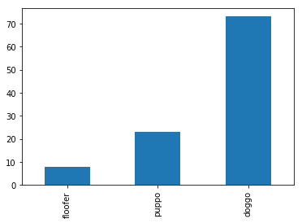

```python
toptype=combine_clean_all['type'].value_counts()
toptype.sort_values(ascending=True)[:3].plot(kind="bar")
```

```python
combine_clean_all.describe()
```

|  | rating_numerator | rating_denominator | favorite_count | retweet_count | img_num | p1_conf | p2_conf | p3_conf |
| --- | --- | --- | --- | --- | --- | --- | --- | --- |
| count | 7884.000000 | 7884.000000 | 7884.000000 | 7884.000000 | 7884.000000 | 7884.000000 | 7.884000e+03 | 7.884000e+03 |
| mean | 12.223237 | 10.477423 | 8964.528666 | 2770.847793 | 1.201928 | 0.594558 | 1.345850e-01 | 6.016556e-02 |
| std | 41.626111 | 6.851971 | 12678.638196 | 4767.126617 | 0.558914 | 0.272075 | 1.010335e-01 | 5.093187e-02 |
| min | 0.000000 | 2.000000 | 80.000000 | 14.000000 | 1.000000 | 0.044333 | 1.011300e-08 | 1.740170e-10 |
| 25% | 10.000000 | 10.000000 | 1962.000000 | 620.000000 | 1.000000 | 0.362925 | 5.328100e-02 | 1.605590e-02 |
| 50% | 11.000000 | 10.000000 | 4090.000000 | 1347.000000 | 1.000000 | 0.587764 | 1.173970e-01 | 4.944380e-02 |
| 75% | 12.000000 | 10.000000 | 11288.000000 | 3185.000000 | 1.000000 | 0.848362 | 1.955730e-01 | 9.157150e-02 |
| max | 1776.000000 | 170.000000 | 143573.000000 | 78378.000000 | 4.000000 | 1.000000 | 4.880140e-01 | 2.734190e-01 |

The variables favorite_count, and retweet_count seem to have significantly greater means than medians. Their standard deviation is even greater than the mean. I think this means the favorite_count and retweet counts are heavily skewed.

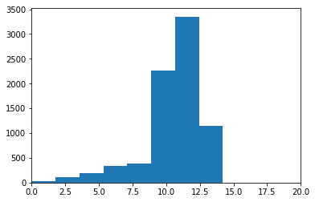

```
12.0      1784
10.0      1668
11.0      1568
13.0      1012
9.0        600
8.0        380
7.0        208
14.0       132
5.0        132
6.0        128
3.0         76
4.0         64
2.0         36
1.0         20
24.0         4
80.0         4
0.0          4
1776.0       4
60.0         4
99.0         4
26.0         4
144.0        4
88.0         4
121.0        4
45.0         4
420.0        4
75.0         4
165.0        4
84.0         4
27.0         4
50.0         4
204.0        4
44.0         4
Name: rating_numerator, dtype: int64
```

```python
plt.hist(x = combine_clean_all.rating_numerator, bins = 1000)
plt.xlim(0,20)
plt.show()
combine_clean_all.rating_numerator.value_counts()
```

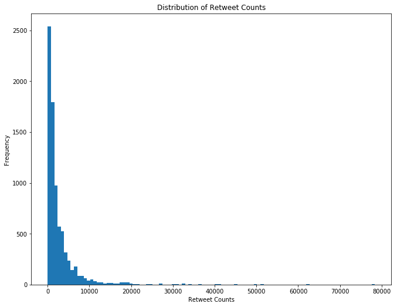

```python
plt.figure(1, figsize = (11, 8.5))
plt.hist(x = combine_clean_all.retweet_count, bins = 100)
plt.title('Distribution of Retweet Counts')
plt.xlabel('Retweet Counts')
plt.ylabel('Frequency')
plt.show()
```

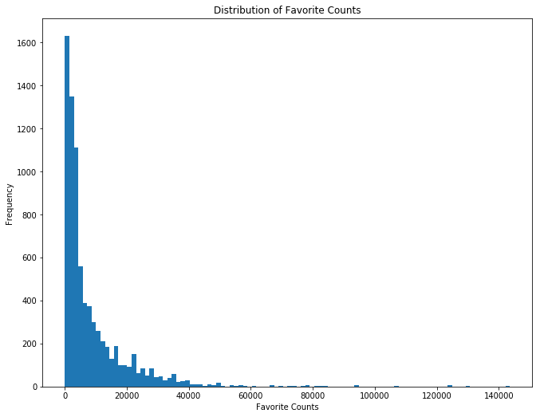

```python
plt.figure(1, figsize = (11, 8.5))
plt.hist(x = combine_clean_all.favorite_count, bins = 100)
plt.title('Distribution of Favorite Counts')
plt.xlabel('Favorite Counts')
plt.ylabel('Frequency')
plt.show()
```

# conclusion :The distribution of retweet_count and favorite_count look similar, but retweet_count is lower than favorite_count. I would guess that these numbers are related to timestamp.

```python
# log transformation of the data
to_log = ['favorite_count', 'retweet_count']
df_logged = combine_clean_all[to_log].applymap(lambda x: np.log10(x))
```

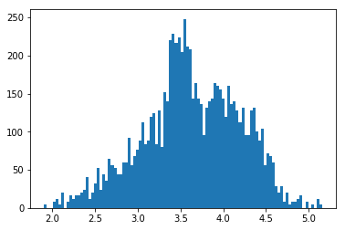

```python
plt.hist(x = df_logged.favorite_count, bins = 100)
plt.show()
```

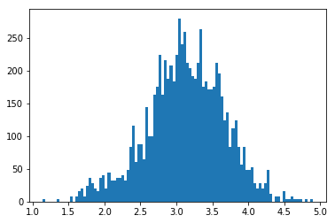

```python
plt.hist(x = df_logged.retweet_count, bins = 100)
plt.show()
```

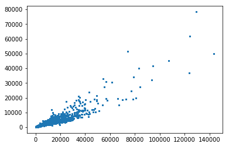

```python
plt.plot(combine_clean_all.favorite_count, combine_clean_all.retweet_count, marker='o', linestyle='', ms=2 )
plt.show()
```

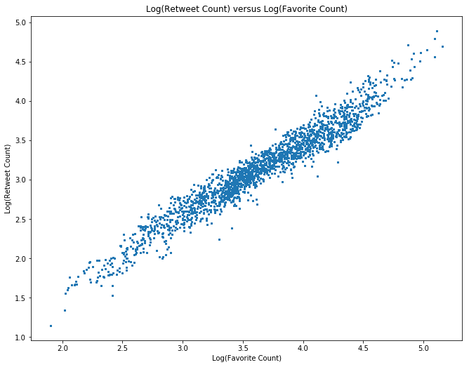

```
0.96853041055316491
```

```python
plt.figure(1, figsize = (11, 8.5))
plt.plot(df_logged.favorite_count, df_logged.retweet_count, marker='o', linestyle='', ms=2 )
plt.title('Log(Retweet Count) versus Log(Favorite Count)')
plt.xlabel('Log(Favorite Count)')
plt.ylabel('Log(Retweet Count)')
plt.show()
np.corrcoef(df_logged.retweet_count, df_logged.favorite_count)[0][1]
```

[figure not shown]

```python
plt.figure(1, figsize = (11, 8.5))
plt.plot(combine_clean_all.timestamp ,df_logged.retweet_count, marker = 'o', linestyle = '', ms = 2)
plt.title('Favorite Count Over Time')
plt.xlabel('Time (Year - Month)')
plt.ylabel('Log(Favorite Count)')
plt.show()
```